# 2. Variantieanalyse (ANOVA)

Table of contents

Het verhaal van dit thema

Werkmaterialen — R-pakketten en functies

Notatie — symbolen voor ANOVA

2.0 Project- en datavoorbereiding

2.1 Eénweg ANOVA

- T1 — Eenweg, tweeweg of niets?
- 2.1.a Inspectie en groepsgemiddelden
- T2 — $F$ als ratio van twee varianties
- 2.1.b Aannamechecks
- 2.1.c De $F$-toets en effectgrootte
- T3 — $\bar{Y}_g$ als voorspelling

2.2 Tweeweg ANOVA — gang_diepte én dagdeel

- 2.2.a Cell means
- T4 — Interactie tekenen
- 2.2.b Het tweeweg-model en de plot
  - Het kruispunt — celgemiddelden, marginalen en effecten in één blik
- T5 — Type I, II, III: maakt het uit?
- 2.2.c De interactie interpreteren — EMM per niveau van de andere factor
- T6 — $\eta^2$ versus $\eta^2_p$
  - Eta-squared versus partial eta-squared in beeld — Venn-diagrammen
- 2.2.d Balanced versus unbalanced — herkennen en wat het ertoe doet
  - Balanced versus unbalanced in beeld — twee Venns

Extra 2A — De fluittoon van de olifant

- Het kruispunt — opnieuw
- T7 — Welke post-hoc, en wanneer?

2.A — Eenweg met drie groepen, contrasten en post-hoc

- T8 — Power, $N$ en het ontwerpen van een ANOVA
- T9 — Welch-ANOVA: wanneer?
- T10 — Niet-significante interactie: wat dan?

R-spiekblad bij ANOVA

- Pakketten en data laden
- Verkenning — celtellingen en groepsgemiddelden
- Aannames checken — Levene en residual plot
- Alternatieven bij geschonden aannames — Welch en Brown-Forsythe
- Model fitten en samenvatten
- Visualisatie — interactieplot
- Post-hoc — Tukey HSD en EMM per niveau
- Contrasten — gerichte vragen

Voorbeeld-tentamenvragen

- Theorie en handreken
- R-practical opdrachtje

Wat blijft liggen

Aan het eind van de dag

Verantwoording

[← Terug naar CountCamp](https://countcamp.org/)·Alle MVDA-thema's

# 2. Variantieanalyse (ANOVA)

- Show All Code
- Hide All Code
- View Source

# Het verhaal van dit thema

Mollen zijn gek op tunnels graven. Ondergronds, ergens tussen de wortels, hield de mol bij hoe snel zijn collega’s groeven. 198 mollen had hij langs zijn nieuwsgierige snorharen voelen schuiven, 198 verschillende — elk één werkuur lang, en bij elk noteerde hij hoeveel centimeter er in dat uur bij kwam. Het is werk, hij houdt het bij.

Bij elke mol noteerde hij ook of die in een ondiepe of een diepe gang zat — diepere bodem is compacter, dat scheelt — en of het ochtend of avond was.

“Maakt het uit hoe diep een mol zit,” mompelde hij, “of het tijdstip van de dag, of allebei?”

De mol kon niet zien. Hij was blind, zoals mollen blind zijn. Maar hij kon goed voelen, en hij kon tellen. Per collega één getal. En nu wilde hij weten: zit er verschil tussen die getallen, en zo ja, waardoor?

Wat de mol berekent heet **analysis of variance** ANOVA, en je stelt elke keer dezelfde drie vragen aan je gegevens:

1. **Voorspellen de groepen samen iets?** — de $F$-toets F-test op het hele model, met $\eta^2$ als hoeveel-zegt-het.
2. **Waar zit het verschil precies?** — contrasten en post-hoc-toetsen tussen specifieke groepen of cellen, en bij meerdere factoren ook de *interactie* interaction.
3. **Klopt het allemaal wel?** — de aannames assumptions: gelijke varianties tussen groepen homogeneity of variance, normaal verdeelde residuen, onafhankelijke observaties.

**Note“ANOVA” alleen is een verwarrende naam**

Strikt genomen valt vrijwel elke statistiek onder ANOVA óf regressie — variatie ontleden in delen die ergens vandaan komen. Het woord wordt pas concreet als we erbij zeggen *welke*:

- **eenweg-ANOVA** one-way ANOVA — één groeperende factor;
- **factorial / meerweg-ANOVA** factorial ANOVA — twee of meer factoren samen, mét interactie;
- **repeated-measures ANOVA** RM-ANOVA — binnen één persoon herhaald gemeten (thema 6);
- **MANOVA** multivariate ANOVA — meerdere uitkomsten tegelijk (thema 5).

Dit hoofdstuk gaat over de eerste twee — **eenweg** en **meerweg** (soms ook *factorial*). Onthoud: zonder dat extra woord blijft “ANOVA” een te ruime container.

**NoteUnivariate — ook al staat het in een MVDA-cursus**

Eenweg- en meerweg-ANOVA zijn nog steeds **univariate** analyses — er is **één** afhankelijke variabele $Y$. Het echte multivariate komt pas in thema 5 (MANOVA), waar je meerdere uitkomsten tegelijk vergelijkt. Tot dan: één $Y$ per analyse.

**NoteHet doel van ANOVA is óók voorspellen — maar via groepsgemiddelden, niet $\hat{Y}$**

In thema 1 (MRA) voorspelden we voor een individu via een vergelijking:
$$\hat{Y}_i = b_0 + b_1 X_{1i} + b_2 X_{2i} + \dots$$
Bij ANOVA voorspellen we óók — alleen niet voor een individu via continue voorspellers, maar voor een **groep** via het groepsgemiddelde:

$$\hat{Y}_{g} = \bar{Y}_g$$

Het groepsgemiddelde $\bar{Y}_g$ is je beste voorspelling voor iedereen in groep $g$. In de regressie-taal (sommige boeken doen dit expliciet via dummy- of effect-codering) heet dit ook wel de **estimated marginal mean** EMM: de modelvoorspelling per cel, gemiddeld over de andere factoren als die er zijn.

Onthoud: ANOVA is geen “toetsings-techniek” en MRA geen “voorspellings-techniek” — **beide voorspellen**, ze gebruiken alleen verschillende voorspelvormen ($\hat{Y}$ versus $\bar{Y}_g$).

**NoteHoe dit hoofdstuk leest**

Dit hoofdstuk volgt dezelfde drie-laagse structuur als thema 1:

1. **Verhaal-frame** — wat de mol doet of denkt.
2. **Algemene vorm** — abstract, statistiek-Latijn met `Y`, `factor1`, `mijn_data`.
3. **Voor onze dieren** — uitvoerend, met `#` hekjes en concrete namen.

Plus de antwoorden in zacht roze (collapse), vragen in oker, leesregels in groen, alarm in oranje, don’ts in rood. T-vragen vlechten zich tussen de hoofdvragen door om je rekenintuïtie te oefenen.

# Werkmaterialen — R-pakketten en functies

*Wat de mol uit zijn keukenkastje pakt*

| Gereedschap | Waar het voor is | Pakket |
| --- | --- | --- |
| `lm()` | Lineair model schatten — ook voor ANOVA | base |
| `Anova(model, type = 3)` | ANOVA-tabel met type III sums of squares | `car` |
| `aov()` | Alternatieve ANOVA-fit, handig voor `TukeyHSD()` | base |
| `aggregate()` | Groepsgemiddelden uitrekenen | base |
| `table()` | Aantallen per cel | base |
| `leveneTest()` | Toets voor gelijke varianties | `car` |
| `TukeyHSD()` | Post-hoc paarsgewijze vergelijkingen | base |
| `etaSquared()` | Effectgrootte $\eta^2$ en $\eta^2_p$ | `lsr` |
| `interaction.plot()` | Snelle visualisatie van een interactie | base |
| `emmeans()` | Estimated marginal means en EMM-uitwerking per niveau | `emmeans` |

**WarningVerwarrend! `anova()`, `Anova()` en `summary()` — drie functies, drie tabellen**

Bij een gefit `lm`-object zijn er **drie** verschillende manieren om naar de modeloutput te kijken, en ze geven *niet* dezelfde tabel:

| Functie | Pakket | Wat geeft het? | Wanneer gebruik je ’m? |
| --- | --- | --- | --- |
| `summary(m)` | base | Coëfficiënten-tabel + $F$-toets voor het hele model + $R^2$. **Geen** $SS$. | Snelle blik op coëfficiënten + modelfit. Voor regressie. |
| `anova(m)` | base | ANOVA-tabel met **Type I** SS (sequentieel). Volgorde van termen telt. | Alleen bij gebalanceerd design — of als je expliciet de volgorde-volgorde-test wilt. Bij regressie zelden. |
| `Anova(m, type = 3)` | `car` | ANOVA-tabel met **Type III** SS (elk effect uniek). Volgorde maakt niet uit. | Standaardkeuze voor ANOVA met ongebalanceerde data — wat in psychologie de norm is. |

Praktijk-vuistregel voor dit hoofdstuk: **gebruik altijd `car::Anova(., type = 3)` voor ANOVA-tabellen.** Voor de coëfficiënten ($b$’s in een regressie-parameterisering, of EMM in factor-parameterisering) blijf je naar `summary(m)` kijken. `anova(m)` (kleine letter) gebruik je vrijwel nooit in dit boek — pas op dat je ’m niet per ongeluk typt en denkt dat het werkt.

**Bijvalletje:** `Anova()` (hoofdletter, `car`) eist `options(contrasts = c("contr.sum", "contr.poly"))` voor correcte Type III hoofdeffecten bij ongebalanceerde data. Die regel staat al boven in het script — laat ’m staan.

**NoteWaarom Type III en niet Type I?**

Bij een **gebalanceerd design** (gelijke aantallen per cel) maakt het niet uit: alle types geven hetzelfde antwoord. Maar zodra het ongebalanceerd is — wat in psychologisch onderzoek vrijwel altijd zo is — wijken Type I, II en III sums of squares uit elkaar. Type III geeft elke voorspeller zijn unieke bijdrage onafhankelijk van de invoervolgorde, en is daarmee de standaardkeuze voor de meeste APA-rapportages. Daarom de regel `options(contrasts = c("contr.sum", "contr.poly"))` bovenaan: die zorgt dat `Anova(., type = 3)` de juiste antwoorden geeft.

# Notatie — symbolen voor ANOVA

**NoteSleutelsymbolen in dit hoofdstuk**

In dit werkboek zie je telkens dezelfde notatie:

- **$\mu_g$** — het *werkelijke* gemiddelde van groep $g$ in de **populatie**. Onbekend; dit is wat we willen weten. Hypothesen worden hierover geformuleerd: $H_0: \mu_1 = \mu_2 = \dots = \mu_k$, “in de populatie zijn alle groepsgemiddelden gelijk.”
- **$\bar{Y}_g$** — het *steekproef-gemiddelde* van groep $g$. Wat `aggregate()` of `mean()` je geeft. Een schatter van $\mu_g$.
- **$\hat{Y}_g = \bar{Y}_g$** — de modelvoorspelling voor elk dier in groep $g$.
- **$F$** — de toetsstatistiek; verhouding van *between-group* variantie tot *within-group* variantie.
- **$df_b, df_w$** — de twee bijhorende vrijheidsgraden: tussen ($k - 1$, met $k$ groepen) en binnen ($N - k$).
- **$\eta^2$** eta-squared — proportie totale variantie die de factor verklaart: een effectgrootte.
- **$\eta^2_p$** partial eta-squared — proportie variantie die de factor verklaart *na aftrek van de andere factoren*. In factorial designs verschilt $\eta^2_p$ van $\eta^2$.
- **$\omega^2$** omega-squared — een minder bevooroordeelde variant van $\eta^2$; in tentamens niet altijd verplicht maar wel netjes om te kennen.

In hypothese-toetsen praten we altijd over de populatie — dus daar staat altijd $\mu_g$. In rapportages over wat je gevonden hebt, schrijf je $\bar{Y}_g$ of $M$.

**TipVuistregels zijn afspraken, geen wetten**

De drempels in dit werkboek zijn breed gangbare conventies — maar niet universeel:

- $\eta^2 \approx .01$ klein, $\approx .06$ middelgroot, $\approx .14$ groot (Cohen, 1988); $\eta^2_p$ analoog;
- Levene significant ($p < .05$): aanname gelijke varianties geschonden;
- $n_{\max}/n_{\min} \geq 1.5$ samen met geschonden Levene maakt de $F$-toets onbetrouwbaar — overweeg dan **Welch-ANOVA** (`oneway.test(..., var.equal = FALSE)`) als alternatief;
- bij herhaalde metingen (thema 6): toets sphericity met Mauchly en pas zo nodig de **Greenhouse-Geisser**-correctie toe op de vrijheidsgraden.

Verschillende vakgroepen, docenten en handboeken kiezen iets andere getallen ($\eta^2 \approx .05$ als groot in heel kleine studies; strengere Levene-kritiek alleen bij hoog ongebalanceerde designs). Als je voor een tentamen of opdracht werkt, **check altijd in je eigen college-sheets** welke drempels je docent of vakgroep hanteert. Wij volgen hier consistent één set, maar dat is een keuze, geen natuurwet.

**NoteCode in dit hoofdstuk — wat moet je kunnen typen?**

Code is standaard **open** als je hem moet kunnen typen op het R-practical-tentamen: `lm()`, `aov()`, `Anova(., type = 3)`, `leveneTest()`, `etaSquared()`, `TukeyHSD()`, `interaction.plot()`, `emmeans()`, `contrast()`, `aggregate()`, `table()`. Code die alleen ter illustratie dient — verkenning, plot-decoratie — staat **ingeklapt** met een knopje “Toon code”. Klap hem open als je nieuwsgierig bent; voor het tentamen hoef je hem niet te reproduceren.

**Volgorde-regel.** Alle `library()`-aanroepen bovenaan je script — vóór elk gebruik van een functie. Schuif je `library(car)` per ongeluk onder een `Anova()`- of `leveneTest()`-regel, dan klaagt R *“could not find function”*. Vervelend, en altijd dezelfde oplossing: pakket boven gebruik.

**TipWerkproces — `opmerkingen_jij.R` ernaast**

Tijdens het werken loop je per definitie tegen dingen aan: een commando dat anders werkt dan je verwacht, een zin in het werkboek die niet helemaal klopt, een vraag waarvan je achteraf denkt *“die had hier eigenlijk moeten staan.”* Open daarvoor een leeg R-script naast je werkbestand, noem het bijvoorbeeld `opmerkingen_jij.R`, en typ daar al je shit in — letterlijke citaten, regelnummers, tijdstempels, je eigen vraag. Het script wordt niet gerund; het is je *kantlijn*. Lever het in bij Ben (per mail of in de gedeelde map) en de volgende werkboek-versie wordt iets minder ruk.

# 2.0 Project- en datavoorbereiding

*De mol bewaart zijn aantekeningen netjes*

Open de meegestuurde projectmap (`02_variantieanalyse/`) en dubbelklik op `02_variantieanalyse.Rproj`. Daarmee staat je werkomgeving klaar: paden kloppen, RStudio kent de juiste werkmap. De data ligt al in `data/`, de helper-functies in `functions/`. Niets te installeren als de vier pakketten (`car`, `lsr`, `emmeans`, `tidyverse`) op je computer staan; anders één keer:

```r
install.packages(c("car", "lsr", "emmeans", "tidyverse"))
```

1. **Open de eerste dataset.**

**Algemene vorm.** Een `.RData`-bestand laden zet het bewaarde object direct in je sessie:

```r
load("data/jouw_data.RData")
str(jouw_data)
```

**Voor onze dieren.** Het bestand bevat een data frame met de naam `mol_werkdag`.

```r
load("data/mol_werkdag.RData")
str(mol_werkdag)
```

```
'data.frame':   198 obs. of  3 variables:
 $ graaftempo : int  40 24 22 32 22 26 38 30 35 34 ...
 $ gang_diepte: Factor w/ 2 levels "ondiep","diep": 1 1 1 1 1 1 1 1 1 1 ...
 $ dagdeel    : Factor w/ 2 levels "ochtend","avond": 1 1 1 1 1 1 1 1 1 1 ...
```

Per geobserveerde mol drie waarden: `gang_diepte` (ondiep/diep), `dagdeel` (ochtend/avond), en `graaftempo` (in cm/uur). `gang_diepte` en `dagdeel` zijn al **factor**-variabelen — R weet dat het categorieën zijn, geen getallen.

**Toon code (verkenning, niet tentamen-stof)**

```r
sapply(mol_werkdag, class)
```

```
 graaftempo gang_diepte     dagdeel
  "integer"    "factor"    "factor"
```

**NoteTechnisch detail: `contr.sum` voor Type-III SS**

Onze setup zet `options(contrasts = c("contr.sum", "contr.poly"))`. Dit is een **technische voorwaarde** voor `car::Anova(., type = 3)` om correcte hoofdeffecten te berekenen bij ongebalanceerde designs. Met R’s default `contr.treatment` zou `Anova(type = 3)` foutieve hoofdeffect-getallen geven. **Voor de inhoudelijke interpretatie maakt het niets uit** — F-toetsen, p-waarden, $\eta^2/\eta^2_p$ en EMM zijn identiek tussen beide; alleen de coëfficiënten in `summary(lm)` worden anders gecodeerd. Onthoud: zet deze regel boven aan je script bij Type-III ANOVA.

# 2.1 Eénweg ANOVA

*De mol vergelijkt twee groepen*

> *“Eerst,” zei de mol, “kijk ik alleen naar de gang-diepte. Maakt het uit of ik in een ondiepe of in een diepe gang zit?”*

**NoteVoor je gaat rekenen — vijf vragen aan jezelf**

Het stappenplan van thema 1, nu uitgebreid met **stap 5**: de techniek-keuze.

1. **Wie of wat wordt er gemeten?** *$198$ verschillende mollen, elk één werkuur lang geobserveerd.*
2. **Wat wordt er gemeten?** *Drie variabelen per mol: gang_diepte, dagdeel, en graaftempo (cm/uur).*
3. **Onafhankelijk of afhankelijk?** *Onderzoeksvraag (deze deelvraag): voorspelt gang_diepte het graaftempo? Dan is **graaftempo** afhankelijk ($Y$), **gang_diepte** onafhankelijk ($X$).*
4. **Meetniveau van elke variabele?** *graaftempo is interval (cm/uur). gang_diepte is nominaal (twee categorieën). dagdeel is nominaal (twee categorieën).*
5. **Welke techniek?** Doorloop de beslisboom:

```
flowchart TD
    A[Hoeveel afhankelijke<br/>variabelen?] -->|één| B[Y meetniveau?]
    A -->|meerdere| Z[MANOVA<br/><i>thema 5</i>]
    B -->|interval| C[X-en meetniveau?]
    B -->|binair| D[Logistic regression<br/><i>thema 4</i>]
    C -->|alleen interval| E[Multiple regression<br/><i>thema 1</i>]
    C -->|alleen nominaal| F[ANOVA<br/><i>dit thema</i>]
    C -->|gemengd| G[ANCOVA<br/><i>thema 3</i>]
    style F fill:#faf3e2,stroke:#c9a05a,stroke-width:2px
```

[output not shown]

**NoteBens pijltjes-overzicht — alle MVDA-technieken in één tabel**

Dezelfde keuze, anders genoteerd. Lees als **predictor(en) (meetniveau) → DV(s) (meetniveau)**:

| # | Predictor(en) | DV(s) | Techniek |
| --- | --- | --- | --- |
|  | dich \|X\| | \|Y\| int | $t$-toets |
|  | nom 3+lvl \|X\| | \|Y\| int | éénweg ANOVA |
| **1** | int \|X X …\| | \|Y\| int | **MRA** — thema 1 |
| **2** | nom \|X X\| | \|Y\| int | **factorial ANOVA** — thema 2 |
| **3** | nom + int \|X C\| | \|Y\| int | **ANCOVA** — thema 3 |
| **4** | bo(in) \|X\| | \|Y\| bin | **LRA** — thema 4 |
| **5** | nom \|X\| | \|Y₁ Y₂ …\| int | **MANOVA** — thema 5 |
| **6** | within-subject momenten | \|Y₁ Y₂ Y₃ Y₄\| int | **RMA** — thema 6 |
| **7** | indirect via $M$ | $X \to M \to Y$ pad | **Mediation** — thema 7 |

$Y$ is interval (graaftempo), $X$ is nominaal (gang_diepte). Antwoord: **ANOVA**. Bij twee categorieën is dat technisch hetzelfde als een $t$-toets met gelijke variantie, maar we doen het via `lm()` zodat we straks naadloos kunnen uitbreiden naar twee factoren.

## T1 — Eenweg, tweeweg of niets?

*Drie miniatuur-onderzoeken — pen-en-papier*

**NoteVraag T1 — Pen-en-papier**

Voor elk onderzoek: bepaal aantal afhankelijke variabelen, het meetniveau van $X$ en $Y$, en kies dan de techniek.

**a)** *De bever vergelijkt drie burcht-types — modder, hout, gemengd — op damlengte (m). Bij $50$ bevers één meting per dier.* Welke techniek?

**b)** *Een klinisch psycholoog vergelijkt drie therapie-types (CGT / EMDR / wachtlijst) en twee leeftijd-categorieën (jong-volwassen / ouder dan $40$) op symptoom-vermindering (schaal $0$–$100$). Bij $120$ cliënten.* Welke techniek?

**c)** *Een HR-team bekijkt drie afdelingen (sales / R&D / support) op zowel werktevredenheid (schaal $1$–$10$) als ervaren werkdruk (schaal $1$–$10$). Bij $90$ medewerkers, beide tegelijk.* Welke techniek?

**CautionAntwoord — open na je eigen poging**

**a)** Eén afhankelijke ($Y =$ damlengte, INT) en één onafhankelijke met drie groepen (NOM). $\Rightarrow$ **eenweg-ANOVA**.

**b)** Eén afhankelijke ($Y =$ symptoom-vermindering, INT) en *twee* onafhankelijke factoren (NOM × NOM). $\Rightarrow$ **tweeweg-ANOVA** (meerweg / factorial). Je krijgt dan twee hoofdeffecten + hun interactie.

**c)** *Twee* afhankelijke variabelen tegelijk (werktevredenheid én werkdruk). Geen ANOVA meer: $\Rightarrow$ **MANOVA** (thema 5).

## 2.1.a Inspectie en groepsgemiddelden

Voordat de mol gaat toetsen, kijkt hij naar wat er feitelijk in de groepen zit.

**Algemene vorm.** Tellingen per groep en groepsgemiddelden van de uitkomstvariabele:

```r
table(mijn_data$factor)                                # aantallen per groep
aggregate(Y ~ factor, data = mijn_data, FUN = mean)    # groepsgemiddelden
```

**Voor onze dieren.**

```r
# Aantal mollen per gang_diepte-groep.
table(mol_werkdag$gang_diepte)
```

```
ondiep   diep
    99     99
```

```r
# Gemiddeld graaftempo per gang_diepte-groep.
aggregate(graaftempo ~ gang_diepte, data = mol_werkdag, FUN = mean)
```

```
  gang_diepte graaftempo
1      ondiep   29.72727
2        diep   20.37374
```

**NoteVragen 2.1**

**a)** Hoeveel mollen zitten er in elke gang_diepte-groep? Is het design gebalanceerd?

**b)** Wat zijn de groepsgemiddelden? Welke groep graaft sneller, en hoe groot is het ruwe verschil?

**CautionAntwoord — open na je eigen poging**

**In gewone woorden.**

1. In de ondiep-groep zitten 99 mollen, in de diep-groep 99. Op de marginale telling exact gelijk; binnen de cellen — daar zien we straks dat de cel-aantallen wel iets uit elkaar lopen.
2. Het gemiddelde tempo in de ondiepe gang ($\bar{Y}_{\text{ondiep}} = 29.73$) ligt hoger dan in de diepe ($\bar{Y}_{\text{diep}} = 20.37$). Een ruw verschil van $9.36$ cm/uur.

**APA-stijl.**

> De marginale aantallen waren gelijk ($n_{\text{ondiep}} = 99$; $n_{\text{diep}} = 99$); de cel-aantallen verschilden licht (zie 2.2). In ondiepe gangen groef de mol gemiddeld sneller ($M = 29.73$ cm/uur) dan in diepe gangen ($M = 20.37$ cm/uur).

## T2 — $F$ als ratio van twee varianties

**NoteVraag T2 — Pen-en-papier**

De $F$-toets in een eenweg-ANOVA is geen mysterie: het is een verhouding tussen twee varianties.

$$F = \frac{\text{MS}_b}{\text{MS}_w} = \frac{\text{SS}_b / df_b}{\text{SS}_w / df_w}$$

Bij de mol: $k = 2$ groepen, $N = 198$ mollen. Stel je leest in een ANOVA-tabel af: $\text{SS}_b = 4331$ en $\text{SS}_w = 19341$.

**a)** Hoeveel zijn $df_b$ en $df_w$?

**b)** Bereken $\text{MS}_b$ en $\text{MS}_w$.

**c)** Bereken $F$. Dit getal moet je straks in de output van `Anova(...)` kunnen vinden.

**CautionAntwoord — open na je eigen poging**

**a)** $df_b = k - 1 = 1$. $df_w = N - k = 198 - 2 = 196$.

**b)** $\text{MS}_b = 4331 / 1 = 4331$. $\text{MS}_w = 19341 / 196 = 98.68$.

**c)** $F = 4331 / 98.68 = 43.89$. Straks zie je in de Type-III-output: $F(1, 196) = 43.89$, $p < .001$. Bingo.

**Inzicht.** $F$ vraagt: “is de spreiding *tussen* de groepsgemiddelden groot ten opzichte van de spreiding *binnen* de groepen?” Als groepen weinig verschillen ten opzichte van wat individuen al onderling verschillen, valt $F \approx 1$.

## 2.1.b Aannamechecks

ANOVA leunt op drie aannames:

- **Normaal verdeelde residuen** binnen elke groep — bij grote $n$ minder kritisch (centrale limietstelling).
- **Gelijke varianties tussen groepen** homogeneity of variance — getoetst met Levene. Komt in thema 3 terug bij ANCOVA: ook daar toetsen we of de varianties van $Y$ over de factor-niveaus ongeveer gelijk zijn, met dezelfde `leveneTest()`-functie.
- **Onafhankelijke observaties** — een design-vraag, niet een data-toets. Herhaalde metingen op één dier? Dan moet je naar thema 6.

**Algemene vorm.**

```r
# Levene's toets voor gelijke varianties (de belangrijkste check)
leveneTest(Y ~ factor, data = mijn_data)

# Visueel: residual plot van het lm-object
plot(lm(Y ~ factor, data = mijn_data), which = 1)
```

**Voor onze dieren.**

```r
# Levene: zijn de varianties tussen de twee groepen ongeveer gelijk?
leveneTest(graaftempo ~ gang_diepte, data = mol_werkdag)
```

```
Levene's Test for Homogeneity of Variance (center = median)
       Df F value Pr(>F)
group   1  0.0825 0.7742
      196
```

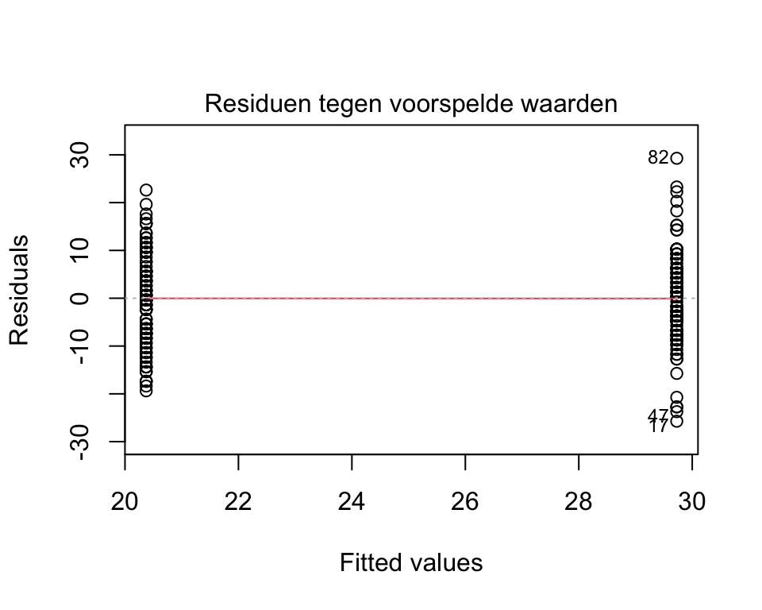

```r
m_diepte <- lm(graaftempo ~ gang_diepte, data = mol_werkdag)
# `sub.caption = ""` haalt de auto-ondertitel met de modelformule weg.
plot(m_diepte, which = 1, sub.caption = "",
     caption = "Residuen tegen voorspelde waarden")
```

**NoteVragen 2.1**

**c)** Is de aanname van gelijke varianties geschonden? Rapporteer Levene.

**d)** Wat zie je in de residual plot — een rustige horizontale band, of iets verdachts?

**CautionAntwoord — open na je eigen poging**

**In gewone woorden.**

3. De Levene-toets is niet significant ($F(1, 196) = 0.08$, $p = .77$): we kunnen niet aantonen dat de varianties verschillen, dus de aanname van gelijke varianties houdt stand.
4. De residual plot toont twee verticale puntenwolken (één per groep), met vergelijkbare spreiding en zonder uitwaaiering. Geen rode vlaggen.

**APA-stijl.**

> De aanname van gelijke varianties was houdbaar, $F(1, 196) = 0.08$, $p = .77$. Visuele inspectie van de residual plot wees niet op afwijkingen van homoscedasticiteit.

**NoteRobuustheid van $F$ — wanneer mag je doorgaan**

De $F$-toets verdraagt heel wat. Twee getallen om te onthouden, één regel voor de richting:

- **Normaliteit** — $F$ is robuust tegen niet-normaal verdeelde residuen zolang **$n \geq 15$ in elke groep**. Onder die grens helpt de centrale limietstelling onvoldoende; dan: **Kruskal-Wallis** als one-way alternatief.
- **Homoscedasticiteit** — $F$ is robuust tegen ongelijke varianties zolang **$n_{\max}/n_{\min} \leq 1.5$**. Voor een echt probleem moeten *beide* gelden: Levene $p < .05$ **én** $n_{\max}/n_{\min} \geq 1.5$. Dan: **Brown-Forsythe** (one-way) of **Welch-ANOVA**, of bij factorial designs de richtingsregel hieronder.
- **Onafhankelijkheid** — niet te redden met een correctie; designkeuze + repeated-measures ANOVA (thema 6).

**Twee-weg richtingsregel** (factorial). Liggen de grootste varianties in de **kleinste** groepen, dan is $F$ te **liberaal** ($p$-waarden te klein); in de **grootste** groepen, dan is $F$ te **conservatief** ($p$-waarden te groot). Conclusie houdt meestal stand, behalve als $p$ tussen $.05$ en $.01$ ligt (liberaal-context) of tussen $.05$ en $.10$ (conservatief-context) — dan met voorzichtigheid rapporteren.

In de woorden van het Exercise Book (p. 42): *“When your groups are large enough: don’t worry!”*

**WarningAlarm: wanneer wordt een geschonden aanname een echt probleem?**

Bij ANOVA volstaat de robuustheid van de $F$-toets meestal voor lichte schendingen, maar kijk uit als:

- **Levene significant** (geschonden) **én** sterk ongelijke groepsgroottes ($n_{\max}/n_{\min} \geq 1.5$). Dan kan de $F$-toets te liberaal of te conservatief worden. Gebruik dan de **Brown-Forsythe**-correctie (`onewaytests::bf.test()`) of een **Welch-ANOVA** (`oneway.test(..., var.equal = FALSE)`).
- **Een groep sterk afwijkt van normaliteit** bij kleine $n$ ($< 15$ per cel). Hier helpt de centrale limietstelling niet meer; overweeg een non-parametrische **Kruskal-Wallis**.
- **Onafhankelijkheid is in twijfel** (bijv. herhaalde metingen, geclusterde data). De gewone ANOVA is hier kansloos; je hebt **repeated measures ANOVA** (thema 6) of een mixed model nodig.

Vuistregel: noem altijd dat je hebt gecheckt, en wat je beslist hebt te doen.

**NoteEerlijke noot — Levene in de cursus-praktijk**

Levene’s toets voor variantie-homogeniteit komt in onze workflow standaard mee — al moet hier opgemerkt: de cursus-lecture geeft expliciet aan *“a statistical test for variance equality exists (Levene’s test). However, we do not use it (at least not in MVDA)”*, terwijl de antwoord-PDF Levene wel rapporteert. We volgen hier de exercise-praktijk (Levene rapporteren), maar de robuustheid van $F$ blijft het hoofdcriterium ($n \geq 15$ + $n_{\max}/n_{\min} \leq 1.5$ — zie callout hierboven). Bij beide schendingen tegelijk: Brown-Forsythe (one-way) of richtingsregel (factorial).

## 2.1.c De $F$-toets en effectgrootte

**Algemene vorm.**

```r
mijn_model <- lm(Y ~ factor, data = mijn_data)
# Contrasts zoals in de uni-oplossing (Type-III toetsen met sum-to-zero).
# Defensief — voor het geval dat een eerder blok de instelling heeft veranderd.
options(contrasts = c("contr.sum", "contr.poly"))
Anova(mijn_model, type = 3)        # ANOVA-tabel met F-toets
etaSquared(mijn_model)             # eta^2 als effectgrootte
```

**Voor onze dieren.**

```r
# Gebruikt 'm_diepte' uit de assumptie-stap hierboven.
# Contrasts zoals in de uni-oplossing (Type-III toetsen met sum-to-zero).
options(contrasts = c("contr.sum", "contr.poly"))
Anova(m_diepte, type = 3)
```

```
Anova Table (Type III tests)

Response: graaftempo
            Sum Sq  Df  F value          Pr(>F)
(Intercept) 124251   1 1259.156       < 2.2e-16 ***
gang_diepte   4331   1   43.887 0.0000000003275 ***
Residuals    19341 196
---
Signif. codes:  0 '***' 0.001 '**' 0.01 '*' 0.05 '.' 0.1 ' ' 1
```

```r
# Effectgrootte: eta-squared.
etaSquared(m_diepte)
```

```
               eta.sq eta.sq.part
gang_diepte 0.1829494   0.1829494
```

**TipVuistregel — eta-squared**

$\eta^2$ is de proportie totale variantie van $Y$ die door de factor wordt verklaard. Vuistwaarden:

- $\eta^2 \approx .01$ — klein effect
- $\eta^2 \approx .06$ — middelgroot effect
- $\eta^2 \approx .14$ — groot effect

Houd rekening met je vakgebied: in experimentele psychologie zijn deze vuistmaten realistisch, in toegepaste contexten ligt de lat soms lager.

**WarningWat staat er in $H_0$ — over de steekproef of over de populatie?**

De $F$-toets in `Anova(., type = 3)` toetst niet iets over de mollen die je hebt gemeten — die kun je gewoon aflezen. Hij toetst iets over de mollen die je *niet* hebt gemeten: de hele populatie waaruit deze steekproef komt. Schrijf de nulhypothese daarom altijd in **populatie-taal**:

$$H_0: \mu_{\text{ondiep}} = \mu_{\text{diep}}$$

— *“in de populatie van alle mollen verschillen ondiepe en diepe gangen niet in graaftempo”*. Niet $\bar{Y}_{\text{ondiep}} = \bar{Y}_{\text{diep}}$ — dat is over je 198 mollen, en die zijn meetbaar ongelijk ($29.73$ versus $20.37$). Eerstejaars-val: $H_0$ schrijven met steekproefgemiddeldes erin. Steekproef = data, populatie = uitspraak.

**WarningTaligheid — let op causale werkwoorden**

Twee veilige formuleringen voor het gevonden effect:

- *“Mollen in ondiepe gangen graven gemiddeld $9.36$ cm/uur sneller dan mollen in diepe gangen”* — vergelijking tussen groepen, observationeel.
- *“Het verschil in gemiddeld graaftempo tussen ondiepe en diepe gangen is $9.36$ cm/uur”* — beschrijving van het verschil, geen oorzaak.

Wat je *niet* mag zeggen zonder experimentele opzet: *“diepe gangen vertragen de mol”*, *“door de diepte daalt het tempo”*, *“ondiepe gangen veroorzaken sneller graven”*. Dat zijn causale werkwoorden — die mag je pas gebruiken als je studie-opzet ze rechtvaardigt (manipulatie, randomisatie, voor-en-na-meting). De mol-data is een momentopname; geen ingreep, geen tijd-as. Mol-keuze voor diepe of ondiepe gang kan zelf met andere kenmerken samenhangen die het tempo verklaren — een derde-variabele-val.

**TipSudoku met je ANOVA-tabel — SS, df, MS en F uit de output halen**

`Anova(m_diepte, type = 3)` print Sum Sq, Df, F en Pr(>F). Het MS-getal (mean square) staat er niet — maar dat is gewoon $SS/df$. Met die **identiteiten** vul je de hele sudoku-tabel terug:

| Cel | Formule | Voor het mol-model |
| --- | --- | --- |
| $SS_b$ (between) | uit `Anova()` regel “gang_diepte” | $4331$ |
| $SS_w$ (within / Residuals) | uit `Anova()` regel “Residuals” | $19341$ |
| $SS_T$ | $SS_b + SS_w$ | $23672$ |
| $df_b$ | $k - 1$ (groepen − 1) | $2 - 1 = 1$ |
| $df_w$ | $N - k$ | $198 - 2 = 196$ |
| $df_T$ | $N - 1$ | $197$ |
| $MS_b$ | $SS_b / df_b$ | $4331 / 1 = 4331$ |
| $MS_w$ | $SS_w / df_w$ | $19341 / 196 = 98.68$ |
| $F$ | $MS_b / MS_w$ | $4331 / 98.68 \approx 43.89$ ✓ |
| $\eta^2$ | $SS_b / SS_T$ | $4331 / 23672 = .183$ ✓ |

Tentamenvraag-format: je krijgt een halve tabel en moet de rest invullen. Wie de identiteiten kent ($SS_T = SS_b + SS_w$, $MS = SS/df$, $F = MS_b/MS_w$, $\eta^2 = SS_b/SS_T$) komt overal uit zonder iets uit het hoofd te leren. *Sudoku.*

**NoteVragen 2.1**

**e)** Is het effect van gang_diepte statistisch significant? Rapporteer $F$, $df$, $p$ en $\eta^2$.

**f)** Is het effect inhoudelijk groot, middelgroot of klein?

**g)** Wat is je voorlopige conclusie over de mol’s vraag?

**CautionAntwoord — open na je eigen poging**

**In gewone woorden.**

5. Het effect van gang_diepte is duidelijk aanwezig. De $F$-toets geeft $F(1, 196) = 43.89$ met $p < .001$ — ruim onder de drempel van $.05$, dus statistisch significant.
6. De effectgrootte is $\eta^2 = .183$: groot ($\geq .14$).
7. Voorlopige conclusie: gang_diepte maakt veel uit. In een ondiepe gang graaft de mol gemiddeld bijna tien centimeter per uur sneller dan in een diepe gang, en dat past bij wat je biologisch zou verwachten — diepere bodem is compacter. Maar pas op: dit is een eenweg-analyse die dagdeel negeert. Wat als dagdeel ertoe doet, en het diepte-effect verschilt tussen ochtend en avond? Dat zoeken we uit in 2.2.

**APA-stijl.**

> Een eenweg-ANOVA toonde een significant en groot effect van gang_diepte op het graaftempo, $F(1, 196) = 43.89$, $p < .001$, $\eta^2 = .183$. In ondiepe gangen ($M = 29.73$ cm/uur) groef de mol gemiddeld $9.36$ cm/uur sneller dan in diepe gangen ($M = 20.37$ cm/uur).

## T3 — $\bar{Y}_g$ als voorspelling

**NoteVraag T3 — Pen-en-papier**

Bij ANOVA is de modelvoorspelling voor elk dier het gemiddelde van zijn groep:

$$\hat{Y}_i = \bar{Y}_{g(i)}$$

Voor de mol-data zijn de groepsgemiddelden $\bar{Y}_{\text{ondiep}} = 29.73$ en $\bar{Y}_{\text{diep}} = 20.37$ cm/uur.

**a)** Een mol heeft gang_diepte = ondiep. Wat is $\hat{Y}$ voor die mol?

**b)** Een andere mol heeft een werkelijk graaftempo van $35$ cm/uur in een diepe gang. Wat is zijn residu $e_i = Y_i - \hat{Y}_i$?

**c)** In de regressievertaling van deze ANOVA met **dummy-codering** (ondiep = 0, diep = 1) zou je krijgen:
$$\hat{Y}_i = b_0 + b_1 \cdot \text{diep}_i$$
Wat zijn $b_0$ en $b_1$ in deze parameterisering?

**CautionAntwoord — open na je eigen poging**

**a)** $\hat{Y} = \bar{Y}_{\text{ondiep}} = 29.73$ cm/uur. Dat is je beste voorspelling voor élke mol in die groep — niets meer, niets minder.

**b)** $e = 35 - 20.37 = 14.63$ cm/uur.

**c)** $b_0 = \bar{Y}_{\text{ondiep}} = 29.73$ (intercept = referentie-groep). $b_1 = \bar{Y}_{\text{diep}} - \bar{Y}_{\text{ondiep}} = 20.37 - 29.73 = -9.36$ (verschil tussen groepen — diep ligt $9.36$ cm/uur lager). Dat $b_1$ — het verschil tussen twee groepsgemiddelden — is precies waar de $F$-toets met één voorspeller op toetst. Met `contr.sum` (sum-to-zero, voor Type III) krijg je andere $b$’s, maar dezelfde voorspellingen $\hat{Y}_g$ en dezelfde $F$.

**Inzicht.** Eenweg-ANOVA *is* een lineair regressiemodel met één gecodeerde factor. De $F$-toets in `Anova(., type = 3)` is in dit geval gewoon de gekwadrateerde $t$-toets op $b_1$.

# 2.2 Tweeweg ANOVA — gang_diepte én dagdeel

*De mol voegt een tweede vraag toe*

> *“Maar wat,” vroeg de mol zich af, “als het diepte-effect ’s avonds anders is dan ’s ochtends? Dan is gang_diepte alleen geen eerlijk verhaal als ik dagdeel negeer.”*

Dat is wat **factorial ANOVA** doet: twee (of meer) nominale factoren tegelijk, plus hun interactie interaction. Een interactie betekent: het effect van factor A is niet hetzelfde voor alle niveaus van factor B. Het effect van A op zichzelf — gemiddeld over de niveaus van B — heet het **hoofdeffect** main effect van A.

In dit hoofdstuk volgen we een conventie: **factor A is de rij-factor, factor B is de kolom-factor**. Bij de mol: $A = \text{gang\_diepte}$ (rijen) en $B = \text{dagdeel}$ (kolommen). Die zelfde A=rij, B=kolom-afspraak gebruiken we straks bij de olifant en bij de dassen.

**TipEerst $2 \times 2$, dán groter — een leervolgorde**

Een factorial design heeft minstens twee factoren met elk twee of meer niveaus. De **kleinst mogelijke** factoriële opzet is $2 \times 2$: vier cellen, twee hoofdeffecten en één interactie. Daarmee zie je *exact* hetzelfde patroon dat in een $2 \times 3$ of $3 \times 4$ design speelt — alleen overzichtelijker.

Daarom de mol-data eerst in $2 \times 2$ (gang_diepte × dagdeel): hier ontstaat het hele begrip *interactie* in vier zinnen. Bij de olifant verderop kruipen we naar $2 \times 3$, en straks bij de dassen een design met meer niveaus. **Vuistregel voor jezelf**: als je een nieuwe techniek leert, begin met het kleinste voorbeeld waarin het patroon nog werkt. Bij multipele regressie is dat *twee* voorspellers (niet drie), bij ANOVA is dat $2 \times 2$. Pas als je daar geen moeite mee hebt, schaal je op.

## 2.2.a Cell means

```r
# Aantallen per cel (= combinatie van gang_diepte x dagdeel)
table(mol_werkdag$gang_diepte, mol_werkdag$dagdeel)
```

```
         ochtend avond
  ondiep      52    47
  diep        49    50
```

```r
# Gemiddelden per cel
aggregate(graaftempo ~ gang_diepte * dagdeel, data = mol_werkdag, FUN = mean)
```

```
  gang_diepte dagdeel graaftempo
1      ondiep ochtend   25.88462
2        diep ochtend   19.42857
3      ondiep   avond   33.97872
4        diep   avond   21.30000
```

**NoteVragen 2.2**

**a)** Welke combinatie van gang_diepte en dagdeel scoort het hoogst? Welke het laagst?

**b)** Is het verschil tussen ondiep en diep even groot in de ochtend als in de avond? Wat zegt dat over een mogelijke interactie?

**CautionAntwoord — open na je eigen poging**

**In gewone woorden.**

1. De combinatie *ondiep + avond* scoort het hoogst ($M = 33.98$ cm/uur). De *diep + ochtend*-cel scoort het laagst ($M = 19.43$).
2. In de ochtend is het verschil tussen ondiep ($25.88$) en diep ($19.43$) modest ($\Delta = 6.46$). In de avond is dat verschil veel groter ($33.98$ vs $21.30$, $\Delta = 12.68$). Dat is een teken van **interactie**: het effect van gang_diepte is groter in de avond dan in de ochtend.

**APA-stijl.**

> Inspectie van de celgemiddelden suggereerde een interactie tussen gang_diepte en dagdeel: in de avond lag het tempo in ondiepe gangen ($M = 33.98$ cm/uur) ruim $12$ cm/uur hoger dan in diepe gangen ($M = 21.30$), terwijl dat verschil in de ochtend kleiner was ($M_{\text{ondiep}} = 25.88$; $M_{\text{diep}} = 19.43$; $\Delta \approx 6.5$).

## T4 — Interactie tekenen

**NoteVraag T4 — Pen-en-papier**

Hieronder vier mini-tabellen met cel-gemiddelden voor een $2 \times 2$ design (factor A heeft twee niveaus $A_1, A_2$; factor B heeft twee niveaus $B_1, B_2$). Voor elk geval: wat zie je — *alleen* hoofdeffect $A$, *alleen* hoofdeffect $B$, *alleen* interactie, of *zowel* hoofd- als interactie-effect?

| Geval | $A_1 B_1$ | $A_1 B_2$ | $A_2 B_1$ | $A_2 B_2$ |
| --- | --- | --- | --- | --- |
| (i) | 4 | 6 | 4 | 6 |
| (ii) | 4 | 6 | 6 | 4 |
| (iii) | 4 | 4 | 6 | 6 |
| (iv) | 4 | 5 | 6 | 9 |

**a)** Schets voor elk geval de interactieplot in je hoofd: x-as $A$, twee lijnen voor $B$. Welk geval heeft *parallelle* lijnen, en welke *snijdende* of *uiteenwijkende* lijnen?

**b)** Welk geval is een *kruis-interactie* (lijnen kruisen)? En een *spreiding-interactie* (lijnen waaieren uit, kruisen niet)?

**CautionAntwoord — open na je eigen poging**

**Vuistregel.** Parallelle lijnen $\Rightarrow$ geen interactie. Niet-parallelle lijnen $\Rightarrow$ interactie. *Hoeveel* niet-parallel zegt iets over de grootte van het interactie-effect; of de toets significant is hangt ook af van $N$.

## 2.2.b Het tweeweg-model en de plot

**Algemene vorm.**

```r
mijn_model <- lm(Y ~ factor1 * factor2, data = mijn_data)
# Contrasts zoals in de uni-oplossing (Type-III toetsen met sum-to-zero).
options(contrasts = c("contr.sum", "contr.poly"))
Anova(mijn_model, type = 3)
etaSquared(mijn_model)
interaction.plot(x.factor = mijn_data$factor1,
                 trace.factor = mijn_data$factor2,
                 response = mijn_data$Y)
```

De `*` in de formule (`factor1 * factor2`) betekent: zowel beide hoofdeffecten als hun interactie meenemen. Schrijf je `factor1 + factor2`, dan krijg je alleen de hoofdeffecten — geen interactie.

**Voor onze dieren.**

```r
# Levene voor de vier-cellen-versie.
leveneTest(graaftempo ~ gang_diepte * dagdeel, data = mol_werkdag)
```

```
Levene's Test for Homogeneity of Variance (center = median)
       Df F value Pr(>F)
group   3   0.696 0.5555
      194
```

```r
m_factorial <- lm(graaftempo ~ gang_diepte * dagdeel, data = mol_werkdag)
# Contrasts zoals in de uni-oplossing (Type-III toetsen met sum-to-zero).
options(contrasts = c("contr.sum", "contr.poly"))
Anova(m_factorial, type = 3)
```

```
Anova Table (Type III tests)

Response: graaftempo
                    Sum Sq  Df   F value           Pr(>F)
(Intercept)         125053   1 1375.5504        < 2.2e-16 ***
gang_diepte           4525   1   49.7733 0.00000000002974 ***
dagdeel               1227   1   13.5006        0.0003085 ***
gang_diepte:dagdeel    479   1    5.2639        0.0228433 *
Residuals            17637 194
---
Signif. codes:  0 '***' 0.001 '**' 0.01 '*' 0.05 '.' 0.1 ' ' 1
```

```r
etaSquared(m_factorial)
```

```
                        eta.sq eta.sq.part
gang_diepte         0.18872565  0.20210717
dagdeel             0.05177013  0.06496975
gang_diepte:dagdeel 0.02021610  0.02641659
```

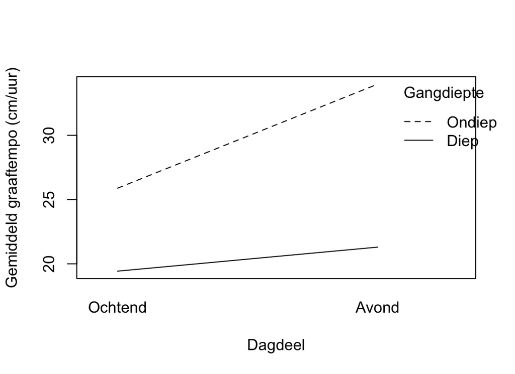

```r
# Interactieplot: x-as is dagdeel (kolom-factor B),
# lijnen voor gang_diepte (rij-factor A).
# Tijdelijke factoren met hoofdletter-niveaus voor leesbare as- en
# legend-labels — onderliggende data blijft ongewijzigd.
.dagdeel_lbl   <- factor(tools::toTitleCase(as.character(mol_werkdag$dagdeel)),
                         levels = tools::toTitleCase(levels(mol_werkdag$dagdeel)))
.diepte_lbl    <- factor(tools::toTitleCase(as.character(mol_werkdag$gang_diepte)),
                         levels = tools::toTitleCase(levels(mol_werkdag$gang_diepte)))
interaction.plot(
  x.factor     = .dagdeel_lbl,
  trace.factor = .diepte_lbl,
  response     = mol_werkdag$graaftempo,
  ylab         = "Gemiddeld graaftempo (cm/uur)",
  xlab         = "Dagdeel",
  trace.label  = "Gangdiepte"
)
```

**TipSpiekbrief — vrijheidsgraden en SS-decompositie voor factorial ANOVA**

Bij een $a \times b$ factorial design (factor $A$ met $a$ niveaus, factor $B$ met $b$ niveaus, $N$ observaties totaal) decomponeer je de totale SS in **vier stukken**: hoofdeffect $A$, hoofdeffect $B$, interactie $A \times B$, en error. De **vrijheidsgraden** lopen mee:

| Bron | $df$ | $SS$ | $MS$ | $F$ |
| --- | --- | --- | --- | --- |
| Hoofdeffect $A$ | $a - 1$ | $SS_A$ | $SS_A / df_A$ | $MS_A / MS_E$ |
| Hoofdeffect $B$ | $b - 1$ | $SS_B$ | $SS_B / df_B$ | $MS_B / MS_E$ |
| Interactie $A \times B$ | $(a-1)(b-1)$ | $SS_{AB}$ | $SS_{AB} / df_{AB}$ | $MS_{AB} / MS_E$ |
| Error (within) | $N - a \cdot b$ | $SS_E$ | $SS_E / df_E$ | — |
| Totaal | $N - 1$ | $SS_T$ | — | — |

**Identiteiten — altijd geldig:**

- $df_T = df_A + df_B + df_{AB} + df_E$
- $SS_T = SS_A + SS_B + SS_{AB} + SS_E$
- $MS = SS / df$ (per regel)
- $F_{\text{effect}} = MS_{\text{effect}} / MS_E$ (drie F’s: één per hoofdeffect, één voor interactie)
- $\eta^2_{\text{effect}} = SS_{\text{effect}} / SS_T$
- $\eta^2_{p, \text{effect}} = SS_{\text{effect}} / (SS_{\text{effect}} + SS_E)$

**Voor de mol ($a = 2$ gang_diepte, $b = 2$ dagdeel, $N = 198$):**

| Bron | $df$ |
| --- | --- |
| gang_diepte ($A$) | $1$ |
| dagdeel ($B$) | $1$ |
| gang_diepte × dagdeel ($A \times B$) | $1$ |
| Error | $194$ |
| Totaal | $197$ |

Check: $1 + 1 + 1 + 194 = 197$. ✓

Bij een $2 \times 3$ design krijg je $df_A = 1$, $df_B = 2$, $df_{AB} = 1 \cdot 2 = 2$, $df_E = N - 6$. Bij $3 \times 4$: $df_A = 2$, $df_B = 3$, $df_{AB} = 6$, $df_E = N - 12$. De **formule** verandert niet — alleen de getallen.

### Het kruispunt — celgemiddelden, marginalen en effecten in één blik

**Het kruispunt** is waar A en B elkaar ontmoeten. Je ziet er vier paden (de cellen), twee marginal-richtingen (rij en kolom) en het centrale punt waar alles samenkomt (de grand mean). Hieronder twee zienswijzen op dezelfde data — de tabel en het profile plot. Kies wat je het meest helpt.

De **2D-tabel** toont elk celgemiddelde plus de **marginalen** (rij-marg = effect van gang_diepte = factor A; kolom-marg = effect van dagdeel = factor B); de **profile plot** dezelfde getallen visueel. Probeer steeds heen-en-weer te zien: een rij-vergelijking in de tabel = een verschuiving van de hele lijn-set omhoog/omlaag in de plot; een kolom-vergelijking = een verschuiving links↔︎rechts; *interactie* = niet-parallelle lijnen.

```r
apa_marginals_table(
  m_factorial,
  factor_A        = "gang_diepte",   # A = rij-factor
  factor_B        = "dagdeel",       # B = kolom-factor
  data            = mol_werkdag,
  dependent_label = "graaftempo (cm/uur)",
  factor_A_label  = "Gangdiepte",
  factor_B_label  = "Dagdeel",
  caption         = "Mol — graaftempo per cel met EMM-marginalen"
)
```

| Gangdiepte | Dagdeel Ochtend | Dagdeel Avond | **Marginaal B** |  |
| --- | --- | --- | --- | --- |
| Ondiep | 25.88 (9.15, 52) | 33.98 (9.42, 47) |  | 29.93 |
| Δ Ondiep − Diep | 6.46 | 12.68 | — |  |
| Diep | 19.43 (9.43, 49) | 21.30 (10.12, 50) | 20.36 |  |
| Marginaal A | 22.66 | 27.64 | 25.15 |  |

*Note.* Mol — graaftempo per cel met EMM-marginalen. Cellen tonen *M* (*SD*, *n*) op basis van graaftempo (cm/uur); rij- en kolom-marginalen zijn ongewogen estimated marginal means (EMM); rechtsonder de grand mean. Hoofdeffect Gangdiepte: *F*(1, 194) = 49.77, *p* < .001 — *H*<sub>0</sub>: alle rij-marginalen gelijk (μ<sub>A⋅</sub>’s gelijk). Hoofdeffect Dagdeel: *F*(1, 194) = 13.50, *p* < .001 — *H*<sub>0</sub>: alle kolom-marginalen gelijk (μ<sub>⋅B</sub>’s gelijk). Interactie Gangdiepte × Dagdeel: *F*(1, 194) = 5.26, *p* = .023 — *H*<sub>0</sub>: cel-patronen additief (geen interactie).

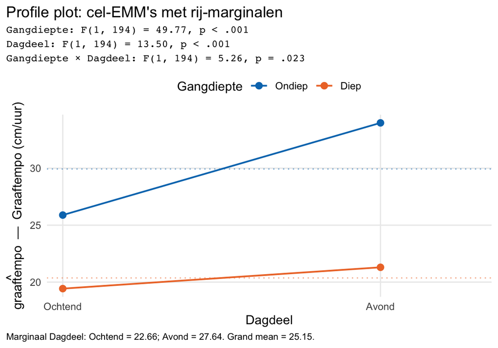

```r
profile_plot_with_marginals(
  m_factorial,
  factor_A         = "gang_diepte",
  factor_B         = "dagdeel",
  data             = mol_werkdag,
  dependent_symbol = "graaftempo",
  dependent_label  = "Graaftempo (cm/uur)",
  factor_A_label   = "Gangdiepte",
  factor_B_label   = "Dagdeel"
)
```

**NoteInteractie = verschil tussen verschillen**

De interactie-toets vraagt: *“is het verschil tussen $A_1$ en $A_2$ ongelijk over de niveaus van $B$?”* In de kruispunt-tabel zie je dat aan de **bold verschilrij**: als die getallen onderling verschillen, is er interactie. Als ze ongeveer gelijk zijn, is er geen interactie.

Concreet bij de mol: $\Delta_{\text{ochtend}} = 6.46$, $\Delta_{\text{avond}} = 12.68$. Het verschil-tussen-verschillen is $12.68 - 6.46 = 6.22$. Dát is wat de interactie-toets onderzoekt — al wordt het in $F$-vorm gerapporteerd. De interactie-coëfficiënt ($b_{\text{int}}$) in een regressie-parameterisering is precies dat verschil-tussen-verschillen, eventueel geschaald met de cel-codering.

Bij een $3 \times 2$ design (zoals de dassen) zit dezelfde logica in de **verschilkolom**: de drie cel-verschillen $\Delta_{\text{zand}}$, $\Delta_{\text{klei}}$, $\Delta_{\text{leem}}$ zijn ongelijk $\Rightarrow$ interactie.

**NoteTabel ↔︎ Plot heen-en-weer**

Met het kruispunt van hierboven (tabel en plot). Houd de A=rij, B=kolom-conventie aan: $A_1 = \text{ondiep}$, $A_2 = \text{diep}$ (rijen); $B_1 = \text{ochtend}$, $B_2 = \text{avond}$ (kolommen).

**a)** Welke twee paden vergelijk je voor het **hoofdeffect van $A$ (gang_diepte)**? Schrijf ze op met hun symbool ($\bar{Y}_{A_1 \cdot}$ etc.).

**b)** Welke twee paden voor het **hoofdeffect van $B$ (dagdeel)**?

**c)** Op welk punt landt een mol waarvan we alleen weten dat hij in conditie $B_1$ (ochtend) is geobserveerd? Wat is je beste voorspelling voor het graaftempo?

**d)** Diezelfde mol, maar nu weten we ook dat hij in een ondiepe gang zat ($A_1$). Op welke kruispunt-cel land je nu?

**e)** Wat zou je in de plot zien als de interactie precies nul was? Schets in woorden.

**f)** Welke kruispunt-cel valt op in de plot? Klopt dat met de $F$-waarde voor de interactie in de tabel?

**CautionAntwoord — open na je eigen poging**

**a)** De twee **rij-marginalen** (laatste kolom van de tabel, *Marginaal B*) vergelijk je: $\bar{Y}_{A_1 \cdot}$ (ondiep, marginaal over dagdeel) versus $\bar{Y}_{A_2 \cdot}$ (diep, marginaal over dagdeel). Concreet: $29.93$ (ondiep) tegen $20.36$ (diep) cm/uur.

**b)** De twee **kolom-marginalen** (laatste rij, *Marginaal A*): $\bar{Y}_{\cdot B_1}$ (ochtend, marginaal over gang_diepte) versus $\bar{Y}_{\cdot B_2}$ (avond). Concreet: $22.66$ (ochtend) tegen $27.64$ (avond).

**c)** Met alleen $B_1$ bekend pak je de kolom-marginaal van $B_1$: $\hat{Y} = \bar{Y}_{\cdot B_1} = 22.66$ cm/uur.

**d)** Met *zowel* $A_1$ als $B_1$ bekend pak je de **cel** zelf: $\hat{Y} = \bar{Y}_{A_1 B_1} = 25.88$ cm/uur. Voor ondiep-ochtend valt het iets boven de kolom-marginaal van $B_1$ — dat past bij de extra informatie dat het ondiep was.

**e)** Bij interactie = nul lopen de lijnen van ondiep en diep **parallel** — het verschil tussen ochtend en avond zou voor ondiep en diep even groot zijn (bv. beide $+5$, of beide $0$).

**f)** Vooral het kruispunt *ondiep × avond* trekt de aandacht: in de avond loopt de ondiep-lijn flink omhoog (van $25.88$ naar $33.98$), terwijl de diep-lijn nauwelijks beweegt (van $19.43$ naar $21.30$). De lijnen lopen niet parallel; in de avond is het diepte-effect dubbel zo groot als in de ochtend. Dat *niet-parallel* zijn correspondeert met $F(1, 194) = 5.26$, $p = .023$ voor de interactie — significant, dus het patroon is niet aan toeval toe te schrijven.

**Vuistregel.** Hoofdeffect = lijnen samen omhoog of omlaag. Interactie = lijnen niet-parallel. Tabel en plot zijn twee talen voor hetzelfde feit.

**NoteVragen 2.2**

**c)** Is de aanname van gelijke varianties geschonden voor de vier cellen? Rapporteer Levene.

**d)** Welke effecten zijn significant? Rapporteer $F$, $df$ en $p$ voor gang_diepte, dagdeel én interactie.

**e)** Hoeveel variantie verklaart elk effect ($\eta^2$ en $\eta^2_p$)?

**f)** Wat zie je in de interactieplot? Lopen de lijnen parallel, of niet?

**CautionAntwoord — open na je eigen poging**

**In gewone woorden.**

3. Levene niet significant ($F(3, 194) = 0.70$, $p = .56$): aanname houdt stand.
4. In de Type III ANOVA-tabel: het hoofdeffect van **gang_diepte** is sterk significant ($F(1, 194) = 49.77$, $p < .001$). Het hoofdeffect van **dagdeel** is ook significant, en duidelijk kleiner van omvang ($F(1, 194) = 13.50$, $p < .001$). De **interactie** $\text{gang\_diepte} \times \text{dagdeel}$ is klein-significant ($F(1, 194) = 5.26$, $p = .023$).
5. Effectgroottes (we rapporteren primair kale $\eta^2$, in lijn met de antwoord-PDF; $\eta^2_p$ ter info erbij): $\eta^2$ gang_diepte $.189$ (groot), dagdeel $.052$ (middelgroot), interactie $.020$ (klein). Ter vergelijking: $\eta^2_p$ ligt iets hoger (gang_diepte $.202$, dagdeel $.065$, interactie $.026$). De volgorde is duidelijk: gang_diepte verklaart veruit het meest, dan dagdeel, dan de interactie als kleinste effect.
6. In de interactieplot zie je de lijnen voor ondiep en diep *niet* parallel lopen: de ondiep-lijn stijgt sterker van ochtend naar avond dan de diep-lijn. Dat is precies wat een interactie visueel betekent: de twee factoren werken niet onafhankelijk.

**APA-stijl.**

> Een $2 \times 2$ tweeweg-ANOVA met gang_diepte en dagdeel als factoren toonde een significant en groot hoofdeffect van gang_diepte, $F(1, 194) = 49.77$, $p < .001$, $\eta^2 = .189$. Het hoofdeffect van dagdeel was eveneens significant, met een middelgrote omvang, $F(1, 194) = 13.50$, $p < .001$, $\eta^2 = .052$. De interactie tussen gang_diepte en dagdeel was klein maar significant, $F(1, 194) = 5.26$, $p = .023$, $\eta^2 = .020$. De aanname van gelijke varianties was houdbaar, $F(3, 194) = 0.70$, $p = .56$.

**TipWat de mol opmerkte**

“Als de interactie significant is, mag ik de hoofdeffecten niet meer in hun eentje interpreteren. Het diepte-effect is in de avond bijna twee keer zo groot als in de ochtend. Eén ongedifferentieerd hoofdeffect rapporteren zou hier liegen — alsof gang_diepte op elk moment van de dag hetzelfde doet.”

## T5 — Type I, II, III: maakt het uit?

**NoteVraag T5 — Pen-en-papier**

In een **gebalanceerd** balanced factorial design (gelijke $n$ per cel) geven Type I, II en III sums of squares Type III sum of squares **identieke** $F$-waarden. In een **ongebalanceerd** unbalanced design (zoals de mol-data — *lichtelijk ongebalanceerd*, $n$ varieert van 47 tot 52 per cel, $n_{\max}/n_{\min} \approx 1.11$) verschillen ze.

**a)** Waarom past Type III bij APA-rapportage van de hoofdeffecten in een ongebalanceerd factorial design? (*Hint: denk aan “uniek na correctie voor de andere effecten”.*)

**b)** Wat zou er fout kunnen gaan als je per ongeluk Type I gebruikt op ongebalanceerde data en de volgorde van factoren in je `lm()`-formule wijzigt?

**CautionAntwoord — open na je eigen poging**

**a)** Type III rekent voor elke term de unieke bijdrage *na correctie voor alle andere termen in het model*. Dat correspondeert met de gangbare APA-vraag: “is dit hoofdeffect / deze interactie nog significant als de andere effecten al meegenomen zijn?” Type III geeft de juiste $F$-toets bij ongebalanceerde data, mits de contrasten op `contr.sum` staan.

**b)** Type I sums of squares zijn *sequentieel*: de eerste factor krijgt al zijn variantie, de tweede alleen wat overblijft, en zo verder. In een ongebalanceerd design verandert daardoor het resultaat als je `Y ~ A + B` schrijft of `Y ~ B + A`. Twee onderzoekers zouden zonder dat ze het doorhebben verschillende $F$- en $p$-waarden voor dezelfde data rapporteren. Type II en Type III zijn invariant onder volgorde-veranderingen; Type III bij voorkeur omdat hij ook de interactie correct corrigeert.

**TipVrijheidsgraden in een $I \times J$ factorial design**

Bij twee factoren met $I$ niveaus (factor $A$) en $J$ niveaus (factor $B$), en $N$ totaal observaties:

| Bron | df |
| --- | --- |
| Factor $A$ | $I - 1$ |
| Factor $B$ | $J - 1$ |
| $A \times B$ | $(I - 1)(J - 1)$ |
| Residu | $N - IJ$ |
| Totaal | $N - 1$ |

Som-check: $(I-1) + (J-1) + (I-1)(J-1) + (N - IJ) = N - 1$.

**Hoofdrekenbaar voorbeeld.** Een $2 \times 3$ design met $n = 10$ per cel: $I = 2$, $J = 3$, $N = 60$. Dan $df_A = 1$, $df_B = 2$, $df_{AB} = 2$, $df_w = 60 - 6 = 54$, $df_{\text{total}} = 59$. Som: $1 + 2 + 2 + 54 = 59$.

**Verifieer bij de fluittoon-data straks.** Olifant ($I = 2$ geslacht, $J = 3$ wind, $N = 134$): $df_A = 1$, $df_B = 2$, $df_{AB} = 2$, $df_w = 134 - 6 = 128$, $df_{\text{total}} = 133$. Check zo dadelijk in Extra 2A of de tweede df van elke $F$-toets inderdaad $128$ is.

## 2.2.c De interactie interpreteren — EMM per niveau van de andere factor

Wanneer de interactie significant is, ga je terug naar de cell means en beschrijf je het patroon zo concreet mogelijk. De cursus-route is: **estimated marginal means per niveau van de andere factor** (`emmeans(model, ~ A | B)`), aangevuld met de cell means uit het kruispunt en de interactieplot. Geen aparte simple-effects-toetsen; die term gebruiken we hier niet.

**WarningHoofdeffecten bij een significante interactie — gekwalificeerd, niet weggelaten**

Een hoofdeffect (bv. *“ondiepe gangen leveren gemiddeld meer cm/uur dan diepe”*) is een uitspraak over de **rij-marginalen** marginal mean — het gemiddelde over alle $B$-condities. Maar als de interactie significant is, **bestaat dat marginal-gemiddelde uit ongelijke patronen**: het verschil tussen ondiep en diep is niet hetzelfde in de ochtend als in de avond.

De cursus-conventie is helder:

1. **Rapporteer alle drie de toetsen** ($F$, $df$, $p$, $\eta^2$) voor hoofdeffect $A$, hoofdeffect $B$, en de interactie. Niets weglaten.
2. **Bij een significante interactie**: voeg de zin *“deze hoofdeffecten worden gekwalificeerd door een significante interactie”* toe (in het Engels: *“qualified by”* — de vaste formulering uit het Exercise Book). Het hoofdeffect is dan dus geen zelfstandige conclusie meer.
3. **Werk de interactie inhoudelijk uit** via de **estimated marginal means per niveau van de andere factor** (`emmeans(model, ~ A | B)`) — niet via aparte simple-effects-toetsen, die term gebruiken we hier niet. Plus de cell means uit het kruispunt en de interactieplot.

Concreet voorbeeld: stel het verschil ondiep − diep is $+6$ in de ochtend en $-2$ in de avond. Het marginal-verschil is $+2$ (gemiddeld over dagdelen). Een hoofdeffect-toets met $p < .05$ rapporteer je wel, maar de **inhoudelijke conclusie** komt uit de cell-patronen — daar zien we dat ondiep alleen ’s ochtends echt voor ligt; in de avond zijn ze gelijk of zelfs omgekeerd. Dat is wat de interactie zegt.

*Bron-formulering*: het Exercise Book (p. 51, p. 54) gebruikt consequent *“qualified by”* voor deze relatie. Onthoud die uitdrukking voor je APA-zin.

**NoteWat ANOVA vergelijkt: EMM, niet descriptives**

Bij een ongebalanceerd design lopen twee soorten gemiddelden uit elkaar:

- **Gewogen marginal mean** (descriptives): $\bar{Y}_{i \cdot}^{\text{gewogen}} = \sum_j n_{ij} \bar{Y}_{ij} / n_{i \cdot}$. De cel-grootte $n_{ij}$ weegt mee. Wat je krijgt als je `aggregate()` of `mean()` op de raw data toepast.
- **Ongewogen marginal mean** (EMM, *estimated marginal mean*): $\bar{Y}_{i \cdot}^{\text{ongewogen}} = \frac{1}{J} \sum_j \bar{Y}_{ij}$. Elke cel krijgt gelijke weeg, ongeacht $n_{ij}$. Wat `emmeans()` rapporteert.

Bij **balanced** (alle $n_{ij}$ gelijk): de twee zijn identiek. Bij **unbalanced**: ze divergeren — soms minimaal, soms substantieel. ANOVA met Type III SS toetst altijd de **EMM-verschillen** — dat zijn de “schone” effecten waarbij elke cel-conditie gelijke invloed heeft op het marginal-gemiddelde, ongeacht hoeveel observaties er toevallig in zaten.

Concreet: stel je hebt $n_{\text{ondiep}} = 100$ mollen in een ondiepe gang (waarvan 80 in conditie A, 20 in B) en $n_{\text{diep}} = 20$ mollen in een diepe gang (waarvan 5 in A, 15 in B). De **descriptives**-mean van A trekt zwaar naar de ondiep-conditie-A (80 van de 85 observaties komen daar vandaan). De **EMM** van A is gewoon $(\bar{Y}_{\text{ondiep,A}} + \bar{Y}_{\text{diep,A}})/2$ — een eerlijke vergelijking ongeacht de mix.

**Daarom**: rapporteer in een ANOVA-context **EMM** voor marginal-effecten, niet de descriptives-tabel. `emmeans(model, ~ factor_A)` geeft je die direct.

**Toon code (illustratie EMM vs descriptives)**

```r
# Descriptives (gewogen, weegt cel-grootte mee).
aggregate(graaftempo ~ gang_diepte, mol_werkdag, FUN = mean)
```

```
  gang_diepte graaftempo
1      ondiep   29.72727
2        diep   20.37374
```

**Toon code (illustratie EMM vs descriptives)**

```r
# EMM (ongewogen, gelijke weeg per cel).
emmeans(m_factorial, ~ gang_diepte)
```

```
 gang_diepte emmean    SE  df lower.CL upper.CL
 ondiep        29.9 0.960 194     28.0     31.8
 diep          20.4 0.958 194     18.5     22.3

Results are averaged over the levels of: dagdeel
Confidence level used: 0.95
```

In de mol-data is het verschil bescheiden — het design is lichtelijk ongebalanceerd ($n_{\max}/n_{\min} \approx 1.11$), dus de twee soorten gemiddelden divergeren maar een fractie ($\bar{Y}^{\text{gewogen}}_{\text{ondiep}} = 29.73$ tegenover $\text{EMM}_{\text{ondiep}} = 29.93$). Bij sterk ongebalanceerde designs kan dat verschil groot worden — en dan rapporteer je de EMM, niet de descriptives.

```r
# Estimated marginal means per cel — EMM-uitwerking per niveau.
# Effect van dagdeel binnen elk niveau van gang_diepte:
emm <- emmeans(m_factorial, ~ dagdeel | gang_diepte)
emm
```

```
gang_diepte = ondiep:
 dagdeel emmean   SE  df lower.CL upper.CL
 ochtend   25.9 1.32 194     23.3     28.5
 avond     34.0 1.39 194     31.2     36.7

gang_diepte = diep:
 dagdeel emmean   SE  df lower.CL upper.CL
 ochtend   19.4 1.36 194     16.7     22.1
 avond     21.3 1.35 194     18.6     24.0

Confidence level used: 0.95
```

```r
# Paarsgewijze vergelijking van dagdeel binnen elke gang_diepte.
pairs(emm)
```

```
gang_diepte = ondiep:
 contrast        estimate   SE  df t.ratio p.value
 ochtend - avond    -8.09 1.92 194  -4.218 <0.0001

gang_diepte = diep:
 contrast        estimate   SE  df t.ratio p.value
 ochtend - avond    -1.87 1.92 194  -0.976  0.3301
```

**NoteVraag 2.2**

**g)** Beschrijf in eigen woorden — niet via de cijfers, maar via wat de mol doet — wat de interactie betekent.

**h)** Bij welke gang_diepte is het effect van dagdeel significant (EMM-vergelijking per niveau van gang_diepte)?

**CautionAntwoord — open na je eigen poging**

**In gewone woorden (g).** In een ondiepe gang verschilt het tempo flink tussen ochtend en avond — ’s avonds graaft de mol daar duidelijk sneller. In een diepe gang maakt het dagdeel nauwelijks uit; de compactere bodem laat zich niet door tijd-van-de-dag overhalen. Het effect van dagdeel hangt dus af van waar hij zit.

Een mogelijke (speculatieve!) interpretatie: in losse, ondiepe grond profiteert hij van de avondkoelte of van het nachtritme; in compacte, diepe bodem wordt het tempo gelimiteerd door de bodem zelf, niet door zijn dagschema.

**EMM-vergelijking per niveau (h).** Bij ondiep is het verschil tussen ochtend en avond significant ($t(194) = -4.22$, $p < .001$, een verschil van $-8.09$ cm/uur — ochtend trager dan avond). Bij diep is het verschil niet significant ($t(194) = -0.98$, $p = .33$, verschil $\approx -1.87$ cm/uur). Het significante interactie-effect zit dus vooral in de ondiep-cellen.

**APA-stijl.**

> De significante interactie weerspiegelde dat het effect van dagdeel op het graaftempo afhing van gang_diepte. In ondiepe gangen lag het tempo in de avond ($M = 33.98$) circa $8$ cm/uur boven dat in de ochtend ($M = 25.88$), en dat verschil was significant ($t(194) = -4.22$, $p < .001$); in diepe gangen werd geen significant dagdeel-verschil gevonden ($M_{\text{avond}} = 21.30$; $M_{\text{ochtend}} = 19.43$; $t(194) = -0.98$, $p = .33$).

**ImportantDon’t: post-hoc tests doen zonder significante $F$**

Wanneer je $k$ groepen vergelijkt en de overall $F$ niet significant is, moet je *niet* alsnog Tukey of een ander post-hoc draaien om “te zien of er ergens toch een verschil zit”. Dat verhoogt je Type-I-foutrisico enorm. De $F$-toets is je gatekeeper: opent hij de deur, dan mag je naar binnen om te kijken welke paren verschillen. Sluit hij hem, dan is het stop.

Uitzondering: in factorial designs kun je per *significant* hoofdeffect of *significante* interactie post-hoc gaan kijken — niet over de hele tabel, alleen waar het ANOVA-bewijs het rechtvaardigt.

**NoteMultiple testing — waarom we corrigeren**

Als je $k$ paren tegelijk vergelijkt op $\alpha = .05$, dan is de kans dat **minimaal één** vals-positief is, gelijk aan $1 - (1 - .05)^k$. Voor 3 paren is dat $1 - .95^3 \approx .14$. Voor 6 paren al $.26$. Daarom: corrigeer.

**Methoden**:

- **Bonferroni**: deel $\alpha$ door $k$. Streng, conservatief, simpel. Toets: $\alpha_{\text{adj}} = .05/k$.
- **Holm-Bonferroni**: sequentieel — sorteer p-waarden, kleinste eerst. Toets eerste tegen $\alpha/k$, tweede tegen $\alpha/(k-1)$, etc. Krachtiger dan Bonferroni.
- **Šidák**: $\alpha_{\text{adj}} = 1 - (1-\alpha)^{1/k}$. Iets minder streng dan Bonferroni.
- **Tukey HSD**: speciaal voor alle paarsgewijze vergelijkingen na ANOVA. Balanceert FWER en power.
- **Dunnett**: alleen versus controle-groep — meer power dan Tukey omdat minder paren.
- **Scheffé**: voor *willekeurige* contrasten (ook lineaire combinaties). Strengst, breedste familie.

**Vuistregel**: Tukey voor “alle paren”. Bonferroni als veilige default voor andere multiple-testing-situaties. Holm als je Bonferroni-power te krap vindt.

## T6 — $\eta^2$ versus $\eta^2_p$

**NoteVraag T6 — Pen-en-papier**

In een tweeweg-ANOVA print `etaSquared()` twee kolommen: `eta.sq` ($\eta^2$) en `eta.sq.part` ($\eta^2_p$).

$$\eta^2 = \frac{\text{SS}_{\text{effect}}}{\text{SS}_{\text{totaal}}}, \qquad
\eta^2_p = \frac{\text{SS}_{\text{effect}}}{\text{SS}_{\text{effect}} + \text{SS}_{\text{residuen}}}$$

**a)** Waarom is $\eta^2_p \geq \eta^2$ altijd?

**b)** Bij de mol-tweeweg-ANOVA: $\text{SS}_{\text{gang\_diepte}} = 4525$, $\text{SS}_{\text{dagdeel}} = 1227$, $\text{SS}_{\text{interactie}} = 479$, $\text{SS}_{\text{residu}} = 17637$. Bereken $\eta^2$ en $\eta^2_p$ voor de interactie. (*Tip: bij $\eta^2$ is de noemer de som van alle effect-SS plus residu-SS; in een gebalanceerd design $\approx \text{SS}_{\text{totaal}}$.*)

**CautionAntwoord — open na je eigen poging**

**a)** $\eta^2_p$ heeft alleen “effect + residu” in de noemer, terwijl $\eta^2$ ook andere effecten in de noemer meeneemt (groter). Voor dezelfde teller geeft dat $\eta^2_p \geq \eta^2$. Bij **eenweg-ANOVA** geldt $\eta^2 = \eta^2_p$ (geen andere effecten); bij meerweg-ANOVA loopt het uiteen.

**b)** Totale SS = $4525 + 1227 + 479 + 17637 = 23868$.

*Kale $\eta^2$ (primair — wat de antwoord-PDF rapporteert):* $\eta^2_{\text{interactie}} = 479 / 23868 = 0.0201 = .020$.

*Partial $\eta^2_p$ (ter vergelijking):* $\eta^2_{p,\text{interactie}} = 479 / (479 + 17637) = 479 / 18116 = 0.0264 = .026$.

Past bij wat `etaSquared(m_factorial)` print.

**Inzicht.** Waarom rapporteer je dan welke? In de antwoord-PDF is **kale $\eta^2$** consequent het primaire getal — die matcht ook direct Cohens vuistwaarden ($.01/.06/.14$). $\eta^2_p$ is gangbaar in SPSS-output (SPSS toont alleen $\eta^2_p$) en bij meta-analyses. Wij geven hier beide; in modelantwoorden zetten we $\eta^2$ voorop en noemen $\eta^2_p$ secundair.

### Eta-squared versus partial eta-squared in beeld — Venn-diagrammen

*Waarom partial eta-squared kan optellen tot meer dan een*

Hoofdrekenbaar voorbeeld om het verschil scherp te krijgen. Stel je hebt een tweeweg-ANOVA met $\text{SS}_A = 30$, $\text{SS}_B = 20$, $\text{SS}_{AB} = 10$, $\text{SS}_w = 40$, en dus $\text{SS}_{\text{totaal}} = 100$.

$$\eta^2_A = \tfrac{30}{100} = .30, \quad \eta^2_B = \tfrac{20}{100} = .20, \quad \eta^2_{AB} = \tfrac{10}{100} = .10$$

Som: $.60$ — past binnen $1$, zoals het hoort bij een netjes verdeelde taart.

**Toon code (illustratie, niet tentamen-stof)**

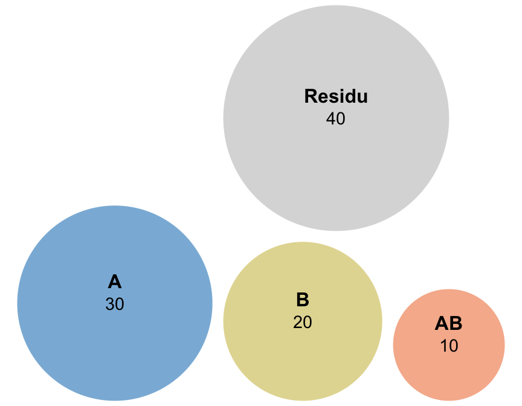

```r
library(eulerr)

fit_eta2 <- euler(c(
  "A"        = 30,
  "B"        = 20,
  "AB"       = 10,
  "Residu"   = 40
))
plot(fit_eta2,
     fills      = list(fill = c("#0077BB", "#CCBB44", "#EE7733", "#BBBBBB"),
                       alpha = 0.55),
     labels     = list(col = "black", font = 2),
     quantities = list(type = "counts", cex = 0.9),
     edges      = list(col = "white", lwd = 2))
```

**$\eta^2_p$**: drie aparte mini-Venns — per effect tel je alleen dát effect plus residu mee. De andere effecten worden weggepoetst voor die berekening, alsof ze er voor *deze* effectgrootte even niet waren.

$$\eta^2_{p,A} = \tfrac{30}{30 + 40} = .43, \quad
\eta^2_{p,B} = \tfrac{20}{20 + 40} = .33, \quad
\eta^2_{p,AB} = \tfrac{10}{10 + 40} = .20$$

Som: $.96$ — bijna over de $100\%$ heen. In andere voorbeelden kan $\sum \eta^2_p$ wél boven $1$ uitkomen; dat is geen fout, het laat zien dat elk effect zijn eigen “submap” krijgt waarin de andere effecten zijn weggehaald.

**Toon code (illustratie, niet tentamen-stof)**

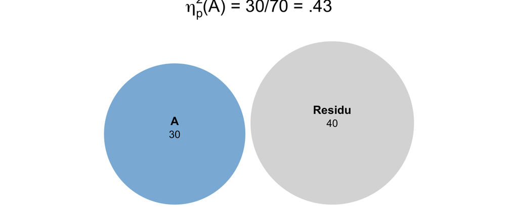

$\eta^2_p$ — per effect een eigen mini-Venn (effect + residu). Andere effecten worden weggepoetst.

```r
library(eulerr)
par(mfrow = c(1, 3), mar = c(1, 1, 2.5, 1))

fit_pA <- euler(c("A" = 30, "Residu" = 40))
plot(fit_pA, main = expression(eta[p]^2 * "(A) = 30/70 = .43"),
     fills = list(fill = c("#0077BB", "#BBBBBB"), alpha = 0.55),
     labels = list(col = "black", font = 2),
     quantities = list(type = "counts", cex = 0.9),
     edges = list(col = "white", lwd = 2))
```

**Toon code (illustratie, niet tentamen-stof)**

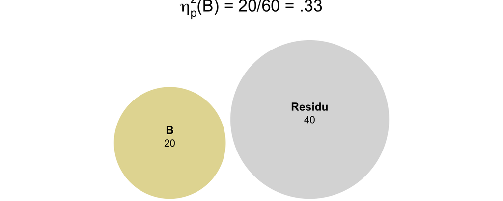

$\eta^2_p$ — per effect een eigen mini-Venn (effect + residu). Andere effecten worden weggepoetst.

```r
fit_pB <- euler(c("B" = 20, "Residu" = 40))
plot(fit_pB, main = expression(eta[p]^2 * "(B) = 20/60 = .33"),
     fills = list(fill = c("#CCBB44", "#BBBBBB"), alpha = 0.55),
     labels = list(col = "black", font = 2),
     quantities = list(type = "counts", cex = 0.9),
     edges = list(col = "white", lwd = 2))
```

**Toon code (illustratie, niet tentamen-stof)**

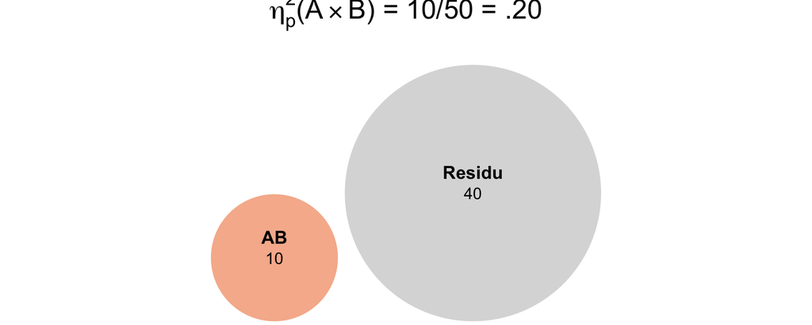

$\eta^2_p$ — per effect een eigen mini-Venn (effect + residu). Andere effecten worden weggepoetst.

```r
fit_pAB <- euler(c("AB" = 10, "Residu" = 40))
plot(fit_pAB, main = expression(eta[p]^2 * "(A" %*% "B) = 10/50 = .20"),
     fills = list(fill = c("#EE7733", "#BBBBBB"), alpha = 0.55),
     labels = list(col = "black", font = 2),
     quantities = list(type = "counts", cex = 0.9),
     edges = list(col = "white", lwd = 2))
```

**Toon code (illustratie, niet tentamen-stof)**

```r
par(mfrow = c(1, 1))
```

**TipDe boodschap**

$\eta^2$ deelt één taart van $100\%$ over alle effecten plus residu — de proporties tellen netjes op tot $\leq 1$. **Dit is wat de antwoord-PDF rapporteert** en wat hier je primaire effectgrootte is. $\eta^2_p$ vraagt per effect: “hoeveel verklaar ik *als de andere effecten er even niet waren*?” Daardoor mag de som boven $1$ uitkomen — handig voor vergelijking met SPSS-output of meta-analyses, maar in modelantwoorden secundair.

## 2.2.d Balanced versus unbalanced — herkennen en wat het ertoe doet

Het balanced/unbalanced-onderscheid is geen hoofddoel van dit thema, maar het is **wel iets om te kunnen herkennen en kort uitleggen**. Sommige opleidingen leggen er nadruk op (vroeger was het zelfs een tentamenklassieker), andere stippen het alleen aan. Check je eigen college-sheets om te weten waar jouw docent op rekent.

**NoteBalanced versus unbalanced — wat is het verschil?**

Een factorial design is **balanced** als de aantallen per cel gelijk zijn ($n_{ij}$ overal gelijk). Bij balanced designs:

- de hoofdeffecten en interactie zijn **orthogonaal** — onafhankelijk van elkaar;
- $\text{SS}_A + \text{SS}_B + \text{SS}_{AB} + \text{SS}_w = \text{SS}_{\text{totaal}}$, schoon opgeteld;
- de drie effecten kunnen “zonder elkaar” gemeten worden — Type I, II en III sums of squares geven **identieke** $F$-waarden.

Bij **unbalanced** designs (verschillende cel-grootten) overlappen de effecten in het verklaarde-variantie-deel. Daarom maakt het uit hoe je de SS toekent (Type I/II/III) — en welke $F$ je rapporteert. In de praktijk is bijna elk psychologisch onderzoek lichtelijk ongebalanceerd (drop-outs, niet-respons), dus **Type III is meestal de juiste keuze**.

**TipHoe herken je een gebalanceerd design — twee routes**

**Route 1 (telling).** Tel de cellen met `table(factor1, factor2)`. Alle cellen gelijk in $n$? Balanced.

**Route 2 (truc).** Bij balanced geldt $n_{ij} = n_{i \cdot} \cdot n_{\cdot j} / N$ voor élke cel — de cel-aantallen zijn precies het product van de marginal counts gedeeld door totaal. Klopt dat niet voor één cel? Dan is het design unbalanced. Handig als je alleen marginal counts hebt.

```r
# Route 1: cel-tellingen direct.
table(mol_werkdag$gang_diepte, mol_werkdag$dagdeel)
```

```
         ochtend avond
  ondiep      52    47
  diep        49    50
```

```r
# Route 2: voorspel cel-aantallen uit marginal counts.
n_total <- nrow(mol_werkdag)
n_diep  <- table(mol_werkdag$gang_diepte)
n_dag   <- table(mol_werkdag$dagdeel)
verwacht_balanced <- outer(n_diep, n_dag) / n_total
round(verwacht_balanced, 2)
```

```
         ochtend avond
  ondiep    50.5  48.5
  diep      50.5  48.5
```

De werkelijke `table()` geeft $52 / 47 / 49 / 50$ — de “verwacht-balanced”-tabel zou $50.5 / 48.5 / 50.5 / 48.5$ geven. De cijfers liggen dichtbij elkaar maar niet exact gelijk: het mol-design is **lichtelijk ongebalanceerd** ($n_{\max}/n_{\min} = 52/47 \approx 1.11$, ruim binnen de $1.5$-robuustheidsgrens). Voor de praktijk: Type III aanhouden, EMM rapporteren, en je bent klaar.

### Balanced versus unbalanced in beeld — twee Venns

*Waar Type I, II, III hetzelfde of verschillend antwoorden*

Een hoofdrekenbaar voorbeeld om de twee situaties naast elkaar te zien.

**Balanced** — twee disjuncte cirkels binnen de totaal-ruimte. $\text{SS}_A = 30$, $\text{SS}_B = 20$, geen overlap. Type I, Type II en Type III geven *identiek* antwoord, want er is geen gedeeld stuk om over te onderhandelen.

**Toon code (illustratie, niet tentamen-stof)**

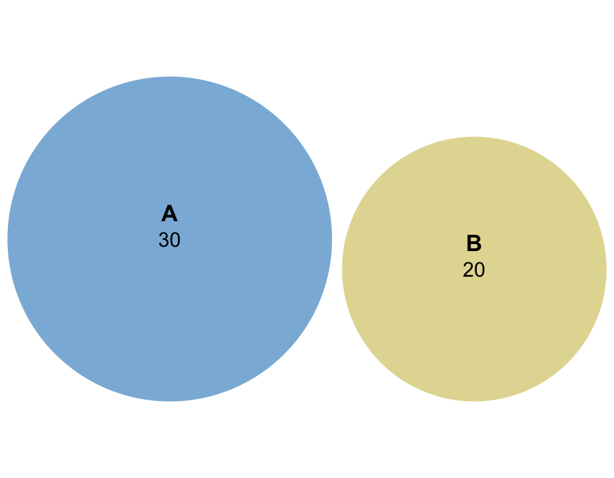

Balanced — $\text{SS}_A = 30$, $\text{SS}_B = 20$, geen overlap. Type I/II/III: identiek.

```r
library(eulerr)

fit_bal <- euler(c(
  "A"   = 30,
  "B"   = 20,
  "A&B" = 0
))
plot(fit_bal,
     fills      = list(fill = c("#0077BB", "#CCBB44"), alpha = 0.55),
     labels     = list(col = "black", font = 2),
     quantities = list(type = "counts", cex = 0.9),
     edges      = list(col = "white", lwd = 2))
```

**Unbalanced** — cirkels overlappen: $\text{SS}_A^{\text{uniek}} = 24$, $\text{SS}_B^{\text{uniek}} = 16$, en een gedeeld stuk $\text{SS}_{A \cap B} = 6$.

- Type I (volgorde $A$ eerst): $A$ krijgt het hele stuk inclusief overlap, $\text{SS}_A = 24 + 6 = 30$; $B$ krijgt alleen het unieke deel, $\text{SS}_B = 16$.
- Type I (volgorde $B$ eerst): $B$ krijgt overlap mee, $\text{SS}_B = 16 + 6 = 22$; $A$ krijgt alleen uniek, $\text{SS}_A = 24$.
- Type III (uniek na correctie voor de ander): beide effecten krijgen alleen hun *unieke* stuk, $\text{SS}_A = 24$ en $\text{SS}_B = 16$. De overlap “hoort bij niemand” — die wordt niet aan $A$ of $B$ toegekend.

Hand-rek-regel: $30 = 24 + 6$, $22 = 16 + 6$. De overlap reist mee met wie als eerste binnenstapt in Type I.

**Toon code (illustratie, niet tentamen-stof)**

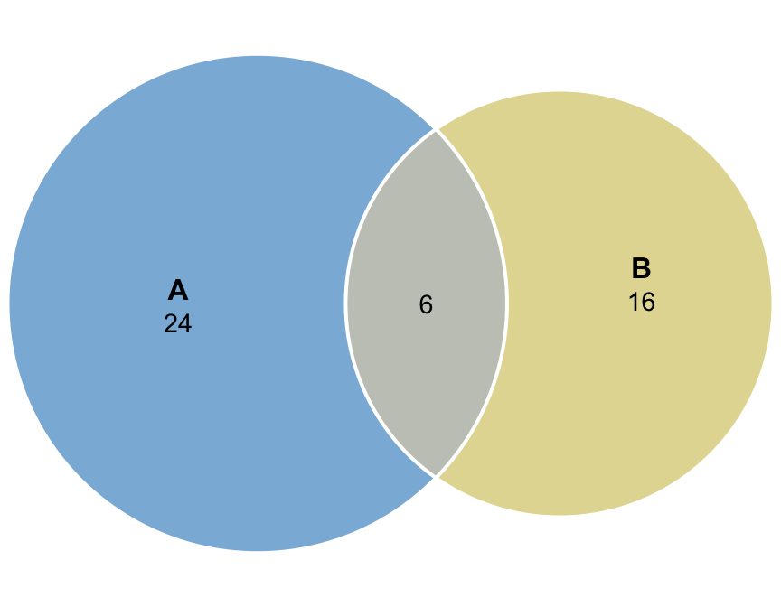

Unbalanced — uniek $A = 24$, uniek $B = 16$, overlap $A \cap B = 6$. Type I (volgorde-afhankelijk) versus Type III (alleen uniek).

```r
library(eulerr)

fit_unb <- euler(c(
  "A"   = 24,
  "B"   = 16,
  "A&B" = 6
))
plot(fit_unb,
     fills      = list(fill = c("#0077BB", "#CCBB44"), alpha = 0.55),
     labels     = list(col = "black", font = 2),
     quantities = list(type = "counts", cex = 0.9),
     edges      = list(col = "white", lwd = 2))
```

**TipWat de plaatjes zeggen**

Bij **balanced** raken de cirkels elkaar niet — er valt niets te onderhandelen, dus alle SS-types vallen samen. Bij **unbalanced** is er een gedeeld stuk; wie dat krijgt hangt af van de SS-keuze. Type III zegt: “geen van beide” — alleen de unieke bijdragen. Vandaar dat Type III de standaard is voor APA-rapportage in ongebalanceerde designs.

# Extra 2A — De fluittoon van de olifant

*Een tweede onderzoek, een nieuwe gast*

> *Tegen het einde van de middag kwam de olifant langs. “Mol,” zei hij, “ik heb ook een onderzoekje gedaan. Ik wilde weten hoe snel dieren reageren als ik een fluittoon laat horen — en of het uitmaakt of er wind staat.”*

De olifant heeft drie wind-condities (geen wind, licht briesje, harde wind), honderdvierendertig dieren, en hij hield bij of ze mannetjes of vrouwtjes waren. Per dier mat hij hoe lang het duurde voor het reageerde op de fluittoon (in milliseconden).

Dit is een $2 \times 3$ factorial design — meer levels op één van de factoren. De analyse is structureel hetzelfde als 2.2, maar met één factor die drie niveaus heeft: dat geeft de mogelijkheid (en bij significantie: noodzaak) van post-hoc tests om uit te zoeken welke wind-niveaus van elkaar verschillen.

```r
load("data/fluittoon_reactie.RData")
str(fluittoon_reactie)
```

```
'data.frame':   134 obs. of  3 variables:
 $ reactietijd: num  4143 5038 7894 1919 5943 ...
 $ geslacht   : Factor w/ 2 levels "mannetje","vrouwtje": 2 2 1 1 2 1 1 1 2 1 ...
 $ wind       : Factor w/ 3 levels "geen wind","licht briesje",..: 1 3 1 2 3 2 3 3 3 2 ...
```

```r
# Cell means in milliseconden
aggregate(reactietijd ~ geslacht * wind, data = fluittoon_reactie, FUN = mean)
```

```
  geslacht          wind reactietijd
1 mannetje     geen wind    3097.841
2 vrouwtje     geen wind    2656.381
3 mannetje licht briesje    4056.794
4 vrouwtje licht briesje    5547.829
5 mannetje    harde wind    6843.620
6 vrouwtje    harde wind    4838.462
```

```r
# Aantallen per cel
table(fluittoon_reactie$geslacht, fluittoon_reactie$wind)
```

```
           geen wind licht briesje harde wind
  mannetje        25            21         24
  vrouwtje        21            25         18
```

```r
leveneTest(reactietijd ~ geslacht * wind, data = fluittoon_reactie)
```

```
Levene's Test for Homogeneity of Variance (center = median)
       Df F value Pr(>F)
group   5  0.1941 0.9643
      128
```

```r
m_olifant <- lm(reactietijd ~ geslacht * wind, data = fluittoon_reactie)
# Contrasts zoals in de uni-oplossing (Type-III toetsen met sum-to-zero).
options(contrasts = c("contr.sum", "contr.poly"))
Anova(m_olifant, type = 3)
```

```
Anova Table (Type III tests)

Response: reactietijd
                  Sum Sq  Df  F value      Pr(>F)
(Intercept)   2683736778   1 438.8361   < 2.2e-16 ***
geslacht         3351448   1   0.5480    0.460484
wind           198203075   2  16.2048 0.000000533 ***
geslacht:wind   66695515   2   5.4529    0.005337 **
Residuals      782794141 128
---
Signif. codes:  0 '***' 0.001 '**' 0.01 '*' 0.05 '.' 0.1 ' ' 1
```

```r
etaSquared(m_olifant)
```

```
                   eta.sq eta.sq.part
geslacht      0.002112573 0.002875488
wind          0.202728058 0.216752177
geslacht:wind 0.062416391 0.078512451
```

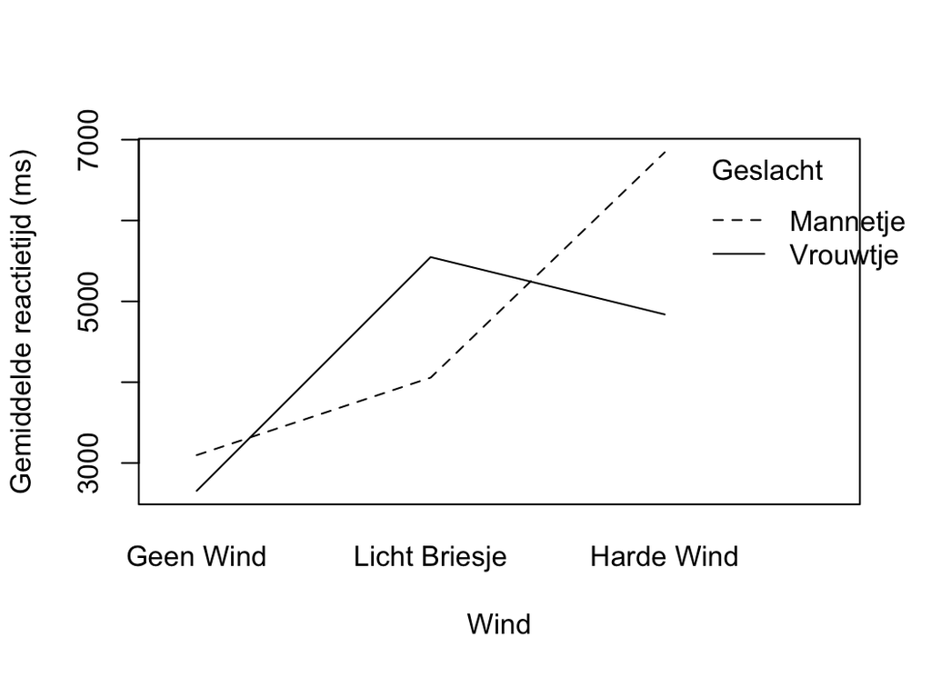

```r
# Tijdelijke factoren met hoofdletter-niveaus voor leesbare as- en
# legend-labels — onderliggende data blijft ongewijzigd.
.wind_lbl     <- factor(tools::toTitleCase(as.character(fluittoon_reactie$wind)),
                        levels = tools::toTitleCase(levels(fluittoon_reactie$wind)))
.geslacht_lbl <- factor(tools::toTitleCase(as.character(fluittoon_reactie$geslacht)),
                        levels = tools::toTitleCase(levels(fluittoon_reactie$geslacht)))
interaction.plot(
  x.factor     = .wind_lbl,
  trace.factor = .geslacht_lbl,
  response     = fluittoon_reactie$reactietijd,
  ylab         = "Gemiddelde reactietijd (ms)",
  xlab         = "Wind",
  trace.label  = "Geslacht"
)
```

### Het kruispunt — opnieuw

Hetzelfde patroon als bij de mol, nu voor het 2 × 3-design met de olifant.

```r
apa_marginals_table(
  m_olifant,
  factor_A        = "geslacht",
  factor_B        = "wind",
  data            = fluittoon_reactie,
  dependent_label = "reactietijd (ms)",
  factor_A_label  = "Geslacht",
  factor_B_label  = "Wind",
  caption         = "Olifant — reactietijd per cel met EMM-marginalen"
)
```

| Geslacht | Wind Geen wind | Wind Licht briesje | Wind Harde wind | **Marginaal B** |  |
| --- | --- | --- | --- | --- | --- |
| Mannetje | 3097.84 (2644.86, 25) | 4056.79 (2350.14, 21) | 6843.62 (2150.03, 24) |  | 4666.08 |
| Δ Mannetje − Vrouwtje | 441.46 | -1491.04 | 2005.16 | — |  |
| Vrouwtje | 2656.38 (2501.64, 21) | 5547.83 (2466.97, 25) | 4838.46 (2732.14, 18) | 4347.56 |  |
| Marginaal A | 2877.11 | 4802.31 | 5841.04 | 4506.82 |  |

*Note.* Olifant — reactietijd per cel met EMM-marginalen. Cellen tonen *M* (*SD*, *n*) op basis van reactietijd (ms); rij- en kolom-marginalen zijn ongewogen estimated marginal means (EMM); rechtsonder de grand mean. Hoofdeffect Geslacht: *F*(1, 128) = 0.55, *p* = .46 — *H*<sub>0</sub>: alle rij-marginalen gelijk (μ<sub>A⋅</sub>’s gelijk). Hoofdeffect Wind: *F*(2, 128) = 16.20, *p* < .001 — *H*<sub>0</sub>: alle kolom-marginalen gelijk (μ<sub>⋅B</sub>’s gelijk). Interactie Geslacht × Wind: *F*(2, 128) = 5.45, *p* = .005 — *H*<sub>0</sub>: cel-patronen additief (geen interactie).

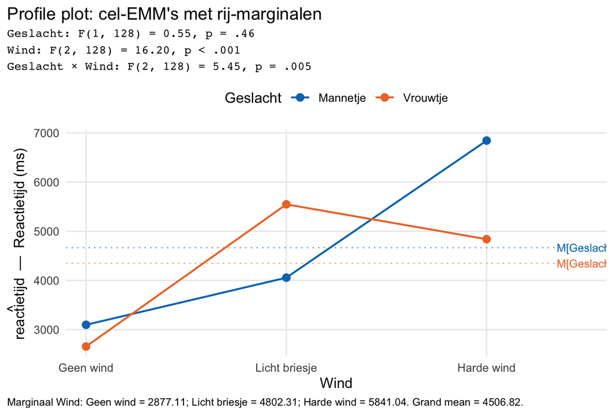

```r
profile_plot_with_marginals(
  m_olifant,
  factor_A         = "geslacht",
  factor_B         = "wind",
  data             = fluittoon_reactie,
  dependent_symbol = "reactietijd",
  dependent_label  = "Reactietijd (ms)",
  factor_A_label   = "Geslacht",
  factor_B_label   = "Wind"
)
```

```r
# Tukey HSD over de wind-factor — mag alleen omdat
# het hoofdeffect van wind significant is.
TukeyHSD(aov(reactietijd ~ wind, data = fluittoon_reactie))
```

```
  Tukey multiple comparisons of means
    95% family-wise confidence level

Fit: aov(formula = reactietijd ~ wind, data = fluittoon_reactie)

$wind
                             diff       lwr      upr     p adj
licht briesje-geen wind  1970.834  710.3904 3231.278 0.0008960
harde wind-geen wind     3087.962 1797.8561 4378.067 0.0000003
harde wind-licht briesje 1117.127 -172.9782 2407.233 0.1038851
```

**NoteVragen Extra 2A**

**a)** Welke effecten zijn significant? Rapporteer $F$, $df$, $p$ en $\eta^2$ per effect.

**b)** Welke wind-paren verschillen significant volgens Tukey HSD?

**c)** Beschrijf de interactie in woorden: hoe verandert het effect van wind tussen mannetjes en vrouwtjes?

**CautionAntwoord — open na je eigen poging**

**In gewone woorden.** Levene niet significant ($F(5, 128) = 0.19$, $p = .96$): de cellen hebben gelijke varianties.

## T7 — Welke post-hoc, en wanneer?

**NoteVraag T7 — Pen-en-papier**

In de fluittoon-data is het hoofdeffect van **wind** (3 niveaus) significant; we kiezen Tukey HSD voor paarsgewijze vergelijkingen.

**a)** Hoeveel paren wind-condities zijn er om te vergelijken? Hoeveel paren in totaal voor een 4-niveau-factor? (Algemeen: $\binom{k}{2}$.)

**b)** Tukey HSD past de $p$-waarde aan voor het aantal vergelijkingen — *familywise error rate* FWER. Wat zou er gebeuren als je in plaats daarvan drie aparte $t$-toetsen zou doen, allemaal op $\alpha = .05$, zonder correctie?

**c)** Welke andere post-hoc-procedures ken je naast Tukey, en wanneer kies je iets anders?

**CautionAntwoord — open na je eigen poging**

**a)** Bij 3 niveaus: $\binom{3}{2} = 3$ paren (geen-licht, geen-hard, licht-hard). Bij 4 niveaus: $\binom{4}{2} = 6$ paren. Het aantal explodeert met $k$.

**b)** Met drie ongecorrigeerde toetsen op $\alpha = .05$ stijgt de kans op minstens één Type-I-fout naar $1 - (1 - .05)^3 \approx .14$. Bij zes toetsen $\approx .26$. Je vindt veel “significant” door toevallige variatie.

**c)** De vier kern-procedures, plus Holm als sequentiële variant:

- **Tukey HSD** — voor *alle* paarsgewijze vergelijkingen na een significant hoofdeffect. Balanceert FWER en power. Gangbare default voor “welke paren verschillen?”. Werkt op `aov()`-objecten.
- **Bonferroni** — deel $\alpha$ door het aantal toetsen $k$. Werkt voor elk multiple-testing-scenario, niet alleen paren. Streng en conservatief, maar simpel uit te leggen. Veilige default als Tukey niet past (bv. niet-paarsgewijze vergelijkingen).
- **Holm-Bonferroni** — sequentiële Bonferroni-variant: sorteer $p$-waarden, toets de kleinste tegen $\alpha/k$, de volgende tegen $\alpha/(k-1)$, etc. Even streng op de FWER, maar *krachtiger* dan vanille-Bonferroni. Vrijwel altijd te verkiezen boven gewone Bonferroni.
- **Scheffé** — voor *willekeurige contrasten*, inclusief lineaire combinaties van groepen, niet alleen paren. Strengst van allemaal omdat de familie het breedst is. Kies hem als je gerichte (maar niet-vooraf-geplande) contrasten wilt toetsen na een significante $F$.
- **Dunnett** — alleen vergelijkingen met één gekozen *controle*-groep; behoudt veel power omdat het aantal vergelijkingen kleiner is dan bij Tukey ($k - 1$ in plaats van $\binom{k}{2}$).

Daarnaast: **Šidák** (iets minder streng dan Bonferroni bij onafhankelijke toetsen), **Games-Howell** (Tukey-variant bij heteroscedasticiteit) en **Benjamini-Hochberg / FDR** (controleert false discovery rate i.p.v. FWER, gangbaar bij grote testfamilies). Check je eigen vakgroep welke procedure de voorkeur heeft.

# 2.A — Eenweg met drie groepen, contrasten en post-hoc

> *De olifant kwam terug, een paar dagen later. “Mol, ik wil de eenweg-versie zien — alleen wind, drie groepen, geen geslacht. Dat hoort bij de canon.”*

Soms is de tweeweg-vraag een omweg en wil je gewoon: één factor met drie of meer niveaus, en dan kijken of er groepsverschillen zijn. We gebruiken dezelfde fluittoon-data, maar nu **alleen** met `wind` als factor.

```r
m_wind <- lm(reactietijd ~ wind, data = fluittoon_reactie)
# Contrasts zoals in de uni-oplossing (Type-III toetsen met sum-to-zero).
options(contrasts = c("contr.sum", "contr.poly"))
Anova(m_wind, type = 3)
```

```
Anova Table (Type III tests)

Response: reactietijd
                Sum Sq  Df F value       Pr(>F)
(Intercept) 2808824185   1 432.002    < 2.2e-16 ***
wind         216810636   2  16.673 0.0000003541 ***
Residuals    851747063 131
---
Signif. codes:  0 '***' 0.001 '**' 0.01 '*' 0.05 '.' 0.1 ' ' 1
```

```r
etaSquared(m_wind)
```

```
        eta.sq eta.sq.part
wind 0.2029003   0.2029003
```

```r
# Cellen
aggregate(reactietijd ~ wind, data = fluittoon_reactie, FUN = mean)
```

```
           wind reactietijd
1     geen wind    2896.305
2 licht briesje    4867.139
3    harde wind    5984.267
```

**TipWat doet `aov()` en waarom verschilt dat van `lm()` plus `Anova()`?**

`aov()` fit hetzelfde model als `lm()`, maar print zijn `summary()` als ANOVA-tabel met **Type I** SS (sequentieel). Voor eenweg-designs of gebalanceerde tweeweg-designs maakt het niet uit. Voor ongebalanceerde tweeweg-designs gebruik je `lm()` + `Anova(., type = 3)`. `TukeyHSD()` werkt alleen op een `aov()`-object — vandaar dat we voor post-hoc óf `aov()` óf `emmeans()` aanroepen.

```r
TukeyHSD(aov(reactietijd ~ wind, data = fluittoon_reactie))
```

```
  Tukey multiple comparisons of means
    95% family-wise confidence level

Fit: aov(formula = reactietijd ~ wind, data = fluittoon_reactie)

$wind
                             diff       lwr      upr     p adj
licht briesje-geen wind  1970.834  710.3904 3231.278 0.0008960
harde wind-geen wind     3087.962 1797.8561 4378.067 0.0000003
harde wind-licht briesje 1117.127 -172.9782 2407.233 0.1038851
```

**NoteConcept — orthogonale contrasten**

Behalve “alle paren vergelijken” kun je ook *gerichte* contrasten kiezen. Stel je hebt drie wind-niveaus en je wilt twee specifieke vragen beantwoorden:

1. **Wind versus geen wind** — gemiddelde van licht-briesje en harde wind versus geen wind: $c_1 = (-2, 1, 1)$.
2. **Licht briesje versus harde wind** — alleen die twee tegen elkaar: $c_2 = (0, -1, 1)$.

Twee contrasten zijn **orthogonaal** orthogonal als $\sum c_{1k} \cdot c_{2k} = 0$. Bij drie niveaus passen er maximaal $k - 1 = 2$ orthogonale contrasten in; samen gebruiken ze alle vrijheidsgraden voor de tussen-groepen-variatie. Orthogonale contrasten zijn elkaars onafhankelijke vragen — ze dubbelen niet. Wanneer je deze contrasten van tevoren vastlegt op grond van theorie heten ze **geplande contrasten** planned contrasts.

`emmeans()` plus `contrast()` laat je dit uitvoeren:

```r
emm <- emmeans(m_wind, ~ wind)
contrast(emm, list(
  wind_vs_geen   = c(-2, 1, 1) / 2,   # gemiddelde wind - geen wind
  licht_vs_hard  = c( 0,-1, 1)        # licht briesje - harde wind
))
```

```r
emm <- emmeans(m_wind, ~ wind)
contrast(emm, list(
  wind_vs_geen   = c(-2, 1, 1) / 2,
  licht_vs_hard  = c( 0, -1, 1)
))
```

```
 contrast      estimate  SE  df t.ratio p.value
 wind_vs_geen      2529 464 131   5.450 <0.0001
 licht_vs_hard     1117 544 131   2.053  0.0421
```

**NoteVraag 2.A**

**a)** Welk contrast is significant, welk niet? Wat zegt dat over de structuur van het wind-effect?

**CautionAntwoord — open na je eigen poging**

Tukey corrigeert voor het feit dat je *drie* paren tegelijk vergelijkt en zet de drempel hoger om de Type-I-fout over de hele familie binnen $\alpha = .05$ te houden (familywise error rate, FWER). Geplande contrasten doen die correctie niet, omdat je vooraf — voordat je de data zag — specifiek déze twee onderzoeksvragen formuleerde. Dat is precies hun didactisch nut: gerichte hypotheses kosten minder power dan een blinde paarsgewijze zoektocht.

Welke is “juist”? Beide. Tukey is exploratief-paarsgewijs en streng; geplande contrasten zijn specifiek en a priori. Dit is een leermoment: hetzelfde paar getallen, twee verschillende correctielogica’s, twee verschillende conclusies — en allebei goed te verdedigen, mits je vooraf je strategie hebt vastgelegd.

## T8 — Power, $N$ en het ontwerpen van een ANOVA

**NoteVraag T8 — Pen-en-papier**

Een onderzoeker ontwerpt een $2 \times 3$ factorial design. Cohen (1988) suggereert voor $\eta^2_p \approx .06$ (middelgroot) en $\alpha = .05$ ongeveer $25$–$30$ observaties per cel om $.80$ power te halen.

**a)** Hoeveel proefpersonen totaal heeft hij minimaal nodig?

**b)** Stel hij heeft $40$ proefpersonen totaal. Wat zijn zijn opties?

**c)** Wat is volgens Tabachnick & Fidell (2007) een te ongebalanceerd design? (*Vuistregel: $n_{\max}/n_{\min}$.*)

**CautionAntwoord — open na je eigen poging**

**a)** $25$ per cel $\times 6$ cellen $= 150$ proefpersonen voor power $\approx .80$ bij middelgroot effect. Bij $30$ per cel: $180$.

**b)** Met $40$ totaal in een $2 \times 3$: gemiddeld $\sim 7$ per cel. Power voor middelgrote effecten zal richting $.20$–$.30$ gaan. Opties:

- Het design vereenvoudigen (bv. één factor weglaten).
- Genoegen nemen met alleen *grote* effecten kunnen detecteren ($\eta^2_p \geq .14$).
- Een *binnen-persoons*-design overwegen, waarbij elke proefpersoon alle condities doorloopt — veel hogere power per N (komt in thema 6).
- Niet doen: door-toetsen tot je iets vindt en dat rapporteren ($p$-hacking).

**c)** Een vuistregel: bij $n_{\max}/n_{\min} > 4$ (de grootste cel meer dan vier keer de kleinste) wordt de $F$-toets onbetrouwbaar als óók Levene significant is. Ook bij $n_{\max}/n_{\min} \approx 1.5$ is voorzichtigheid gepast. Tabachnick en Fidell adviseren: balanceer waar je kunt, en als het echt niet kan, gebruik Type III en rapporteer expliciet.

## T9 — Welch-ANOVA: wanneer?

**NoteVraag T9 — Pen-en-papier**

`oneway.test()` in R doet standaard een **Welch-ANOVA** — een variant van eenweg-ANOVA die *niet* aanneemt dat varianties gelijk zijn.

**a)** In welke twee situaties is Welch beter dan de gewone (Student-)ANOVA?

**b)** Wat verandert er aan de vrijheidsgraden $df_w$? (*Hint: niet meer $N - k$.*)

**c)** Voor de mol-één-weg-vraag (alleen `gang_diepte`, twee groepen): bij twee groepen is Welch-ANOVA equivalent aan een bekende $t$-toets-variant. Welke?

**CautionAntwoord — open na je eigen poging**

**a)** Welch is robuust tegen (1) ongelijke varianties en (2) ongelijke groepsgroottes. Beide tegelijk is precies waarbij gewone ANOVA misgaat.

**b)** Welch berekent een gecorrigeerd $df_w$ via de Welch-Satterthwaite-formule, dat lager is dan $N - k$ en niet noodzakelijk een geheel getal. Bij ernstige varianti-ongelijkheid kan $df_w$ flink dalen — wat conservativer toetst.

**c)** Bij $k = 2$ is Welch-ANOVA equivalent aan **Welch’s $t$-toets** (de “ongelijke variantie”-versie van de Student-$t$). De Student-$t$ met `var.equal = TRUE` en gewone eenweg-ANOVA met $k = 2$ geven identieke $p$-waarden — en dat is gekwadrateerd in $F$.

## T10 — Niet-significante interactie: wat dan?

**NoteVraag T10 — Pen-en-papier**

Stel je doet een $2 \times 2$ tweeweg-ANOVA en de interactie is *niet* significant ($F(1, 100) = 1.20$, $p = .270$). Hoofdeffect $A$ wel ($F(1, 100) = 18.50$, $p < .001$). Hoofdeffect $B$ ook ($F(1, 100) = 9.40$, $p = .003$).

**a)** Mag je nu de hoofdeffecten *los* interpreteren? Waarom (niet)?

**b)** Een collega zegt: “Haal de interactie uit het model — een additief model is *parsimonieuser* en geeft scherpere hoofdeffecten.” Wanneer is dat advies gepast, en wanneer niet?

**c)** Een andere collega zegt: “Interactie weglaten is gevaarlijk; je verstopt mogelijke kruis-effecten.” Heeft hij gelijk?

**CautionAntwoord — open na je eigen poging**

**a)** Ja. Bij niet-significante interactie zijn de hoofdeffecten *zinvol los te interpreteren*: het effect van $A$ is voor alle $B$-niveaus statistisch hetzelfde (binnen toeval), en omgekeerd. Je rapporteert ze als “het effect van $A$ was X, ongeacht $B$.” Dit is precies het tegenovergestelde van een significante interactie.

**b)** Soms gepast: in een **a-priori additief model** (theorie zegt dat $A$ en $B$ onafhankelijk werken) en bij grote sample-size kan het rapporteren van een additief model schoner zijn. Het werkt minder goed bij kleine samples — een niet-significante interactie betekent niet dat hij *afwezig* is, alleen dat we hem niet konden detecteren. Bij twijfel: laat hem in het model maar rapporteer: “interactie niet significant; hoofdeffecten konden onafhankelijk worden geïnterpreteerd.”

**c)** Ten dele. Je verstopt potentieel niets als je de interactie hebt *getoetst* en niet-significant vond, en rapporteert dat. Je verstopt wel iets als je hem stilletjes weglaat zonder te tonen dat hij niet significant was. Voor de lezer is altijd wenselijk: rapporteer de hele tabel inclusief interactie, en vertel pas in de tekst dat je de hoofdeffecten los interpreteert.

# R-spiekblad bij ANOVA

*Alle commando’s op één plek*

## Pakketten en data laden

```r
# Pakketten activeren — één keer per sessie.
library(car)         # voor Anova(., type = 3) en leveneTest()
library(lsr)         # voor etaSquared()
library(emmeans)     # voor estimated marginal means en EMM-uitwerking per niveau

# Type III SS vereist sum-to-zero contrasten op factoren.
options(contrasts = c("contr.sum", "contr.poly"))

# Eerste dataset laden — object 'mol_werkdag' verschijnt vanzelf.
load("data/mol_werkdag.RData")

# Tweede dataset laden — object 'fluittoon_reactie' verschijnt vanzelf.
load("data/fluittoon_reactie.RData")

# Snelle inkijk: structuur, factor-niveaus, eerste waarden.
str(mol_werkdag)
```

## Verkenning — celtellingen en groepsgemiddelden

```r
# Aantallen per groep (eenweg) of per cel (factorial).
table(mol_werkdag$gang_diepte)
table(mol_werkdag$gang_diepte, mol_werkdag$dagdeel)

# Groepsgemiddelden / cel-gemiddelden van Y.
aggregate(graaftempo ~ gang_diepte, data = mol_werkdag, FUN = mean)
aggregate(graaftempo ~ gang_diepte * dagdeel, data = mol_werkdag, FUN = mean)
```

## Aannames checken — Levene en residual plot

```r
# Levene's toets voor gelijke varianties.
leveneTest(graaftempo ~ gang_diepte, data = mol_werkdag)
leveneTest(graaftempo ~ gang_diepte * dagdeel, data = mol_werkdag)

# Residual plot van het lm-object.
plot(lm(graaftempo ~ gang_diepte, data = mol_werkdag), which = 1)
```

## Alternatieven bij geschonden aannames — Welch en Brown-Forsythe

```r
# Welch-ANOVA — robuust tegen ongelijke varianties.
oneway.test(graaftempo ~ gang_diepte, data = mol_werkdag, var.equal = FALSE)

# Brown-Forsythe — alternatieve robuuste F-toets bij ongelijke varianties.
# install.packages("onewaytests")  # eerste keer
onewaytests::bf.test(graaftempo ~ gang_diepte, data = mol_werkdag)

# Kruskal-Wallis — non-parametrisch alternatief bij kleine n + non-normaliteit.
kruskal.test(graaftempo ~ gang_diepte, data = mol_werkdag)
```

## Model fitten en samenvatten

```r
# Eenweg-ANOVA via lm() + Anova().
m1 <- lm(graaftempo ~ gang_diepte, data = mol_werkdag)
# Contrasts zoals in de uni-oplossing (Type-III toetsen met sum-to-zero).
# Defensief — herhaal vlak voor elke Type-III-aanroep voor het geval dat
# een eerder blok of package-load de instelling heeft veranderd.
options(contrasts = c("contr.sum", "contr.poly"))
Anova(m1, type = 3)
etaSquared(m1)

# Tweeweg-ANOVA — let op de * voor hoofdeffecten + interactie.
# A = gang_diepte (rij-factor), B = dagdeel (kolom-factor).
m2 <- lm(graaftempo ~ gang_diepte * dagdeel, data = mol_werkdag)
# Contrasts zoals in de uni-oplossing (Type-III toetsen met sum-to-zero).
options(contrasts = c("contr.sum", "contr.poly"))
Anova(m2, type = 3)
etaSquared(m2)
```

## Visualisatie — interactieplot

```r
interaction.plot(
  x.factor     = mol_werkdag$dagdeel,
  trace.factor = mol_werkdag$gang_diepte,
  response     = mol_werkdag$graaftempo,
  ylab         = "Gemiddeld graaftempo (cm/uur)",
  xlab         = "Dagdeel",
  trace.label  = "gang_diepte"
)
```

## Post-hoc — Tukey HSD en EMM per niveau

```r
# Tukey HSD: alleen na significant hoofdeffect, op aov-object.
TukeyHSD(aov(reactietijd ~ wind, data = fluittoon_reactie))

# Estimated marginal means + paarsgewijze vergelijkingen per cel.
emm <- emmeans(m2, ~ dagdeel | gang_diepte)
emm
pairs(emm)

# Bonferroni-correctie via emmeans
pairs(emmeans(m_wind, ~ wind), adjust = "bonferroni")

# Holm-Bonferroni
pairs(emmeans(m_wind, ~ wind), adjust = "holm")

# Scheffé
pairs(emmeans(m_wind, ~ wind), adjust = "scheffe")

# Generiek: p-vector aanpassen
p.adjust(p_vector, method = "bonferroni")
p.adjust(p_vector, method = "holm")
p.adjust(p_vector, method = "BH")  # Benjamini-Hochberg, FDR-controle
```

## Contrasten — gerichte vragen

```r
# Gerichte contrasten via emmeans + contrast().
m_wind <- lm(reactietijd ~ wind, data = fluittoon_reactie)
emm <- emmeans(m_wind, ~ wind)
contrast(emm, list(
  wind_vs_geen   = c(-2, 1, 1) / 2,
  licht_vs_hard  = c( 0, -1, 1)
))
```

# Voorbeeld-tentamenvragen

*Even oefenen op tentamen-toon*

Onderaan dit hoofdstuk staan vier korte theorievragen in tentamen-stijl en één mini R-opdracht. Geen Tellegen-frame meer — student-aan-tentamen-modus. Hou de vuistregels uit dit hoofdstuk paraat: $\eta^2 \geq .14$ groot, $.06$ middel, $.01$ klein; Levene $p < .05$ flagt; Tukey alleen na significant hoofdeffect.

## Theorie en handreken

**NoteVraag E1 — $F$-tabel aflezen**

Een bever bestudeert een vergelijking van vier soorten dam-bouwhout (eik / wilg / berk / esdoorn) op damstevigheid (kN/m). Hij rapporteert dit fragment uit een eenweg-ANOVA-tabel.

```
R
Anova Table (Type III tests)

Response: stevigheid
            Sum Sq  Df  F value  Pr(>F)
houtsoort     84.6   3    7.230  0.0002 ***
Residuals    312.0  80
```

Hoeveel proefdammen ($N$) hadden in totaal aan deze studie meegedaan?

1. $80$
2. $83$
3. $84$
4. $86$

**CautionAntwoord — open na je eigen poging**

**c) $84$.** $df_w = N - k = 80$, met $k = 4$ groepen, dus $N = 80 + 4 = 84$.

**NoteVraag E2 — eta-squared interpreteren**

In een onderzoek bij de uilenwacht naar het effect van **lichtsterkte** (3 niveaus) op **alertheid** lezen we: $F(2, 87) = 6.40$, $p = .003$, $\eta^2 = .128$.

Welke conclusie volgt het beste uit deze cijfers?

1. Het effect is statistisch significant en zeer groot; lichtsterkte verklaart bijna alles.
2. Het effect is statistisch significant en middelgroot tot groot in inhoudelijke zin; lichtsterkte verklaart $\sim 13\%$ van de variantie.
3. Het effect is statistisch niet significant; verder onderzoek nodig.
4. Eta-squared boven $.10$ wijst altijd op multicollineariteit.

**CautionAntwoord — open na je eigen poging**

**b)** Eta-squared van $.128$ ligt tussen middel ($.06$) en groot ($.14$); $\eta^2$ is letterlijk de proportie variantie verklaard, dus $\sim 13\%$. Optie a overdrijft, c miskent het significante $p$, d verwart $\eta^2$ met VIF.

**NoteVraag E3 — interactie-grafiek lezen**

Bij de kerkuilen worden $80$ uilen onderzocht in een $2 \times 2$ design: **veld** (open / bos) en **maan** (volle / nieuwe). Uitkomst: aantal succesvolle vangsten per nacht. De interactieplot ziet er zo uit:

- veld = open, maan = volle: $M = 4.5$
- veld = open, maan = nieuwe: $M = 4.7$
- veld = bos, maan = volle: $M = 6.8$
- veld = bos, maan = nieuwe: $M = 3.1$

Welke uitspraak past het best bij dit patroon?

1. Hoofdeffect veld, maar geen interactie.
2. Hoofdeffect maan, maar geen interactie.
3. Vooral een interactie: het effect van maan is sterk verschillend in open versus bos.
4. Geen enkel effect; alle cellen verschillen verwaarloosbaar.

**CautionAntwoord — open na je eigen poging**

**c)** In het open veld is het maan-effect klein ($4.5 \to 4.7$, +$0.2$). In het bos juist sterk negatief bij nieuwe maan ($6.8 \to 3.1$, −$3.7$). Lijnen niet parallel $\Rightarrow$ duidelijke interactie. De marginalen suggereren ook hoofdeffecten, maar bij een sterke interactie zoals deze interpreteer je ze niet los.

**NoteVraag E4 — wanneer post-hoc?**

Een ecoloog doet een eenweg-ANOVA met **vier vegetatie-types** als factor en **soortenrijkdom** als uitkomst. Hij rapporteert: $F(3, 76) = 1.81$, $p = .15$, $\eta^2 = .067$.

Hij overweegt of hij Tukey HSD nu mag draaien om alsnog te zien welke vegetatie-types onderling verschillen.

Wat is het juiste advies?

1. Ja, want $\eta^2 = .067$ is middelgroot.
2. Ja, mits hij Bonferroni-correctie toepast in plaats van Tukey.
3. Nee: de overall $F$ is niet significant; post-hoc verhogen het Type-I-foutrisico zonder toetsbasis.
4. Nee, want bij vier groepen mag je alleen Scheffé gebruiken, niet Tukey.

**CautionAntwoord — open na je eigen poging**

**c)** De gangbare conventie: post-hoc-toetsen alleen ná een significant ANOVA-hoofdeffect. Met $p = .15$ is er geen toetsbasis om verder paren te onderzoeken — dat zou neerkomen op $p$-hacking via een achterdeurtje. Een matige $\eta^2$ kan in theorie wijzen op een te kleine $N$ (lage power); het juiste antwoord is dan repliceren met meer dieren, niet de huidige data verder uitpluizen.

## R-practical opdrachtje

*De dassen-burcht*

**NoteVraag E5 — Mini-ANOVA bij de dassen**

Een ecoloog onderzoekt hoe lang dassen ’s nachts foerageren — hun **foerageertijd** (in minuten) — onder twee factoren: **bodem** (zand / klei / leem; drie niveaus) en **seizoen** (zomer / winter; twee niveaus). Bij $78$ dassen is per dier de gemiddelde foerageertijd vastgelegd, samen met het bodemtype waarop ze hun burcht hebben en het seizoen van meting. De dataset staat in `data/dassen_burcht.RData` en bevat het object `dassen_burcht`. Sla je R-commando’s op in één scriptbestand: `dassen.R`. Gebruik $\alpha = .05$.

**a)** Is de aanname van gelijke varianties houdbaar? Rapporteer Levene.

**b)** Voer een $3 \times 2$ tweeweg-ANOVA uit (Type III). Welke effecten zijn significant? Rapporteer de toetsstatistiek, de vrijheidsgraden en de *p*-waarde per effect.

**c)** Welk effect heeft de grootste $\eta^2$? Wat is de inhoudelijke grootte (klein / middel / groot)?

**d)** Maak een `interaction.plot()` met `bodem` op de x-as en lijnen voor `seizoen`. Beschrijf in één zin het patroon.

**CautionAntwoord — open na je eigen poging**

```r
load("data/dassen_burcht.RData")
leveneTest(foerageertijd ~ bodem * seizoen, data = dassen_burcht)
```

```
Levene's Test for Homogeneity of Variance (center = median)
      Df F value Pr(>F)
group  5  0.6783 0.6413
      72
```

```r
m_das <- lm(foerageertijd ~ bodem * seizoen, data = dassen_burcht)
# Contrasts zoals in de uni-oplossing (Type-III toetsen met sum-to-zero).
options(contrasts = c("contr.sum", "contr.poly"))
Anova(m_das, type = 3)
```

```
Anova Table (Type III tests)

Response: foerageertijd
               Sum Sq Df  F value         Pr(>F)
(Intercept)   1083733  1 4288.548      < 2.2e-16 ***
bodem           13676  2   27.059 0.000000001722 ***
seizoen          5496  1   21.749 0.000013946484 ***
bodem:seizoen    2238  2    4.428        0.01536 *
Residuals       18195 72
---
Signif. codes:  0 '***' 0.001 '**' 0.01 '*' 0.05 '.' 0.1 ' ' 1
```

```r
etaSquared(m_das)
```

```
                  eta.sq eta.sq.part
bodem         0.34377376   0.4307134
seizoen       0.13238695   0.2256226
bodem:seizoen 0.05588776   0.1095272
```

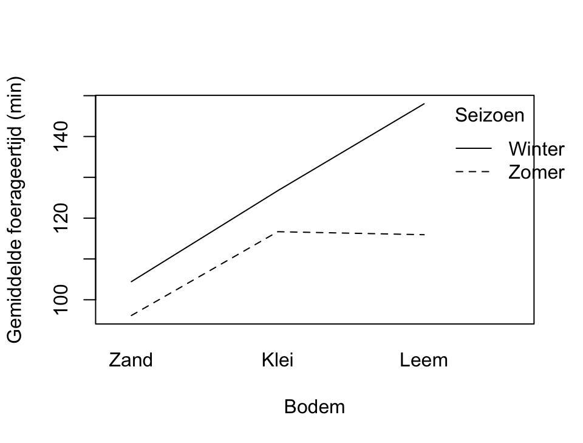

```r
# Tijdelijke factoren met hoofdletter-niveaus voor leesbare as- en
# legend-labels — onderliggende data blijft ongewijzigd.
.bodem_lbl   <- factor(tools::toTitleCase(as.character(dassen_burcht$bodem)),
                       levels = tools::toTitleCase(levels(dassen_burcht$bodem)))
.seizoen_lbl <- factor(tools::toTitleCase(as.character(dassen_burcht$seizoen)),
                       levels = tools::toTitleCase(levels(dassen_burcht$seizoen)))
interaction.plot(
  x.factor     = .bodem_lbl,
  trace.factor = .seizoen_lbl,
  response     = dassen_burcht$foerageertijd,
  ylab         = "Gemiddelde foerageertijd (min)",
  xlab         = "Bodem",
  trace.label  = "Seizoen"
)
```

Het kruispunt voor het dassen-design (3 × 2):

```r
apa_marginals_table(
  m_das,
  factor_A        = "bodem",
  factor_B        = "seizoen",
  data            = dassen_burcht,
  dependent_label = "foerageertijd (min)",
  factor_A_label  = "Bodem",
  factor_B_label  = "Seizoen",
  caption         = "Dassen — foerageertijd per cel met EMM-marginalen"
)
```

| Bodem | Seizoen Zomer | Seizoen **Δ Zomer − Winter** | Seizoen Winter | **Marginaal B** |  |
| --- | --- | --- | --- | --- | --- |
| Zand | 96.14 (17.88, 14) | -8.30 | 104.44 (16.54, 13) |  | 100.29 |
| Klei | 116.68 (17.48, 13) | -10.05 | 126.72 (16.33, 13) | 121.70 |  |
| Leem | 115.94 (14.01, 12) | -32.07 | 148.02 (12.01, 13) | 131.98 |  |
| Marginaal A | 109.59 | — | 126.39 | 117.99 |  |

*Note.* Dassen — foerageertijd per cel met EMM-marginalen. Cellen tonen *M* (*SD*, *n*) op basis van foerageertijd (min); rij- en kolom-marginalen zijn ongewogen estimated marginal means (EMM); rechtsonder de grand mean. Hoofdeffect Bodem: *F*(2, 72) = 27.06, *p* < .001 — *H*<sub>0</sub>: alle rij-marginalen gelijk (μ<sub>A⋅</sub>’s gelijk). Hoofdeffect Seizoen: *F*(1, 72) = 21.75, *p* < .001 — *H*<sub>0</sub>: alle kolom-marginalen gelijk (μ<sub>⋅B</sub>’s gelijk). Interactie Bodem × Seizoen: *F*(2, 72) = 4.43, *p* = .015 — *H*<sub>0</sub>: cel-patronen additief (geen interactie).

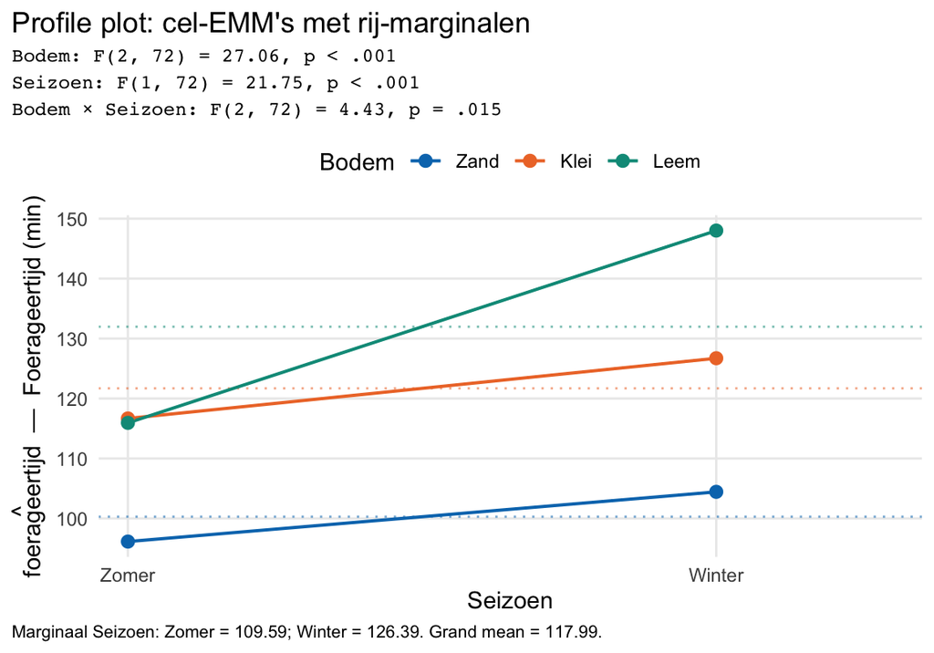

```r
profile_plot_with_marginals(
  m_das,
  factor_A         = "bodem",
  factor_B         = "seizoen",
  data             = dassen_burcht,
  dependent_symbol = "foerageertijd",
  dependent_label  = "Foerageertijd (min)",
  factor_A_label   = "Bodem",
  factor_B_label   = "Seizoen"
)
```

**a)** De aanname van gelijke varianties is houdbaar (Levene niet significant — zie output).

**b)** Alle drie de effecten zijn significant: hoofdeffect **bodem** $F(2, 72) = 27.06$, $p < .001$; hoofdeffect **seizoen** $F(1, 72) = 21.75$, $p < .001$; **interactie** bodem $\times$ seizoen $F(2, 72) = 4.43$, $p = .015$.

**d)** Op zandbodem is het verschil tussen zomer en winter klein; op leem is het verschil substantieel — dassen op leem foerageren in de winter veel langer dan in de zomer. Dat is de interactie die de $F$-toets bevestigt.

> Een $3 \times 2$ tweeweg-ANOVA toonde significante hoofdeffecten van bodem, $F(2, 72) = 27.06$, $p < .001$, $\eta^2 = .344$, en seizoen, $F(1, 72) = 21.75$, $p < .001$, $\eta^2 = .132$. De interactie tussen bodem en seizoen was eveneens significant, $F(2, 72) = 4.43$, $p = .015$, $\eta^2 = .056$. De aanname van gelijke varianties was houdbaar volgens Levene’s toets.

# Wat blijft liggen

*Onderwerpen die buiten dit thema blijven*

ANOVA is een groot huis met veel zijdeuren. Wat dit thema je gaf is de hoofdingang — eenweg, tweeweg, interactie, post-hoc, contrasten. Wat hierachter ligt en in dit werkboek **niet** behandeld wordt:

- **Robuuste ANOVA** — `WRS2::t1way` en verwante procedures op basis van M-estimators of trimmed means. De Welch-ANOVA in T9 is hiervan een lichte variant; de volledige robust-toolbox blijft hier buiten.
- **Niet-parametrische alternatieven** — Kruskal-Wallis (eenweg) en Friedman (repeated). Worden in de bachelor-statistiek behandeld; we slaan ze hier over omdat ANOVA bij grote $N$ relatief robuust is.
- **Permutatie-toetsen** — een alternatief inferentie-frame zonder normaliteits-aanname; je herschudt je groepslabels en bouwt zo een empirische nulverdeling.
- **Mixed-effects modellen** — voor geclusterde data (zie de aanname onafhankelijkheid). In thema 6 (RMA) wordt RMA-ANOVA terloops aangewezen als “speciaal geval van een mixed-effects model met random intercept”, maar de bredere aanpak (random slopes, kruisgeneste data, `lme4::lmer`) komt nergens uitgewerkt voor.
- **Bayesiaanse ANOVA** — een alternatief inferentie-frame waarbij effecten als verdelingen worden geschat. `BayesFactor::anovaBF` is een toegankelijke ingang.
- **Effectgrootte voorbij $\eta^2$ en $\eta^2_p$** — $\omega^2$ (minder bias bij kleine steekproeven), generalized $\eta^2$ (geschikter voor mixed designs).
- **Power-analyse vooraf** — `pwr::pwr.anova.test` voor sample-size-planning. Belangrijk in onderzoeksmethoden, hier niet behandeld.

Voor verdieping: Tabachnick & Fidell (2007); Wilcox (2017, *robust methods*); Maxwell, Delaney & Kelley (2017, *design and analysis*).

# Aan het eind van de dag

Toen de zon onderging, schoof de mol zijn aantekeningen onder een wortel.

“En, mol?” vroeg de olifant, die nog even was blijven staan.

“Diepte maakt veel uit,” zei de mol, “en dagdeel ook iets. En het diepte-effect is in de avond groter dan in de ochtend.” Hij dacht even na. “Ik had die laatste niet gemerkt als ik alleen naar gang-diepte had gekeken.”

“En ik,” zei de olifant, “weet nu dat de wind er flink toe doet, en dat het bij sommige wind-condities anders werkt voor mannetjes dan voor vrouwtjes.”

Ze zaten samen. Het werd langzaam donker. Ergens in de verte ritselde een blad.

# Verantwoording

Dit werkboek is geschreven voor studenten die variantieanalyse leren via R. De didactische lijnen volgen de gangbare opbouw van Nederlandse universitaire MVDA-cursussen; alle voorbeelden, datasets, vragen en formuleringen in dit hoofdstuk zijn origineel. De gebruikte drempels en formules zijn standaard statistische conventies; verwijzingen naar Cohen (1988) en Tabachnick & Fidell (2007) volgen de gebruikelijke citaatpraktijk in dit veld.

*Versie: May 2026 — CountCamp Lab*